# Landscape analysis example

Trond Simensen

03 11 2019

### Analysis of variation of landscape properties

# Coastal plains

All four axes in the 4-dimensional GNMDS ordination of the KS457 dataset were confirmed by DCA. GNMDS ordination had Procrustes SS = 0.0363 and seven unstable OUs (which switched positions between the two best GNMDS solutions).

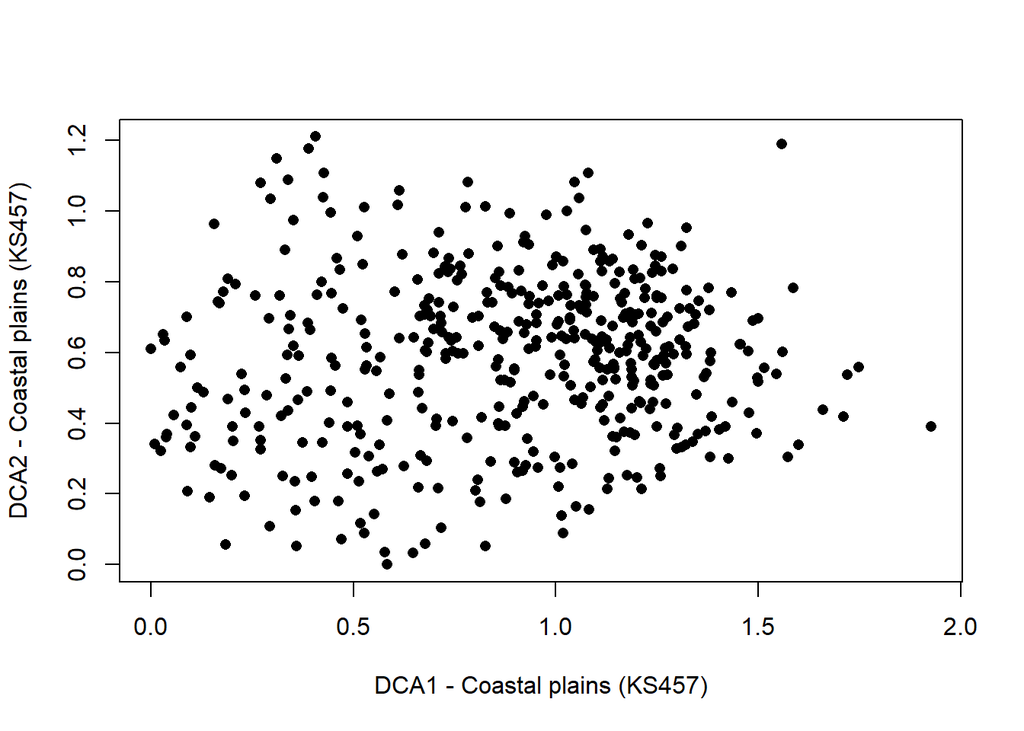

There were no visible artifacts in the ordination charts. The correlation analysis, the vector charts and the iso-line charts show a strong first axis related to land use (infrastructure and agricultural character) that appears to be conditioned by an underlying geo-ecological gradient from inner to outer coast. Second axis is strongly related to relief.

```r
kable(corr.matrise) %>%
  kable_styling(bootstrap_options = c("striped", "hover", "condensed", font_size = 9))
```

| Variable | Description | GNMDS1 | GNMDS2 | GNMDS3 | GNMDS4 |
| --- | --- | --- | --- | --- | --- |
| Gab_nae | No commercial buildings | 0.6345 | -0.1164 | -0.0294 | -0.0092 |
| Gab_fi | No fisheries-related buildings | 0.3166 | -0.0682 | 0.1576 | -0.0607 |
| Gab_a | PA built-up | 0.7328 | -0.0514 | -0.0632 | -0.0397 |
| Flat_a | PA flat terrain | -0.0920 | -0.5626 | 0.2041 | 0.1333 |
| Vmag_a | PA regulated magazine | 0.0638 | 0.0458 | -0.0305 | 0.0313 |
| Vei_b_a | PA road | 0.6270 | -0.0403 | 0.0441 | 0.0764 |
| Ktkmo_a | PA thick layer of till | 0.2496 | 0.0351 | 0.0825 | 0.2250 |
| Tpi1l_a | PA depressions | 0.1171 | 0.5584 | -0.0046 | -0.0476 |
| Tpi1h_a | PA convex terrain | 0.0115 | 0.4749 | -0.2350 | -0.2408 |
| Tpi1_mp | Terrain form TPI1, numerical, mean | -0.0787 | 0.0753 | -0.1994 | -0.1974 |
| Stroms_a | PA strong ocean current | 0.0130 | -0.0281 | 0.1729 | 0.1029 |
| Stromn_a | PA normal ocean current | -0.5201 | -0.1313 | 0.1621 | -0.0064 |
| Stroml_a | PA weak ocean current | 0.1040 | 0.1434 | -0.2647 | 0.0612 |
| River_a | PA large river | 0.1955 | -0.1176 | 0.1526 | 0.1342 |
| Sti_a | PA trail, path | 0.1018 | -0.0506 | -0.0624 | 0.0061 |
| Steep_a | PA steep terrain/slope | 0.0664 | 0.6571 | -0.0831 | -0.0625 |
| Kskred_a | PA landslide soil | -0.0134 | 0.2100 | 0.3115 | 0.1613 |
| Setr_s | No summer mountain pasture | 0.1523 | 0.0005 | 0.0472 | -0.0194 |
| Sefr_a | PA old buildings | 0.5703 | -0.0920 | -0.0622 | -0.1033 |
| Rug3_m | Terrain ruggedness VRM3, mean | 0.0404 | 0.6617 | -0.0259 | -0.1666 |
| Rr1_m | Altitudinal range | 0.0752 | 0.7185 | -0.0293 | 0.0011 |
| Brich_a | PA lime-rich bedrock | 0.0159 | 0.0992 | -0.1475 | 0.1324 |
| Bpoor_a | PA lime-poor bedrock geology | 0.0641 | -0.0189 | 0.0535 | -0.2003 |
| Rd_anl_a | PA reindeer husbandry facilities | 0.0533 | 0.1007 | 0.0276 | 0.1174 |
| Bplu_a | PA plutonic rock | 0.0541 | -0.1586 | 0.0252 | -0.3956 |
| Bvul_a | PA volcanic rock | 0.1879 | -0.0016 | -0.0087 | -0.1046 |
| Bavstn_a | PA sedimentary rock | 0.1844 | -0.1174 | -0.1346 | 0.1115 |
| Bomd_a | PA metamorphic rock | -0.0386 | 0.1951 | 0.0493 | 0.1713 |
| Land_a | PA terrestrial area | 0.6629 | 0.0369 | 0.0937 | -0.1296 |
| Build_a | PA built-up area | 0.4657 | -0.1377 | -0.0752 | -0.0331 |

[output cut: 54 more lines]

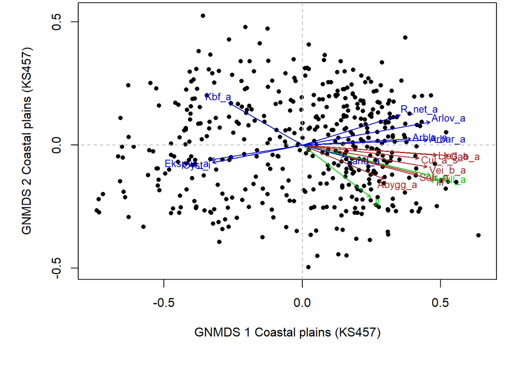

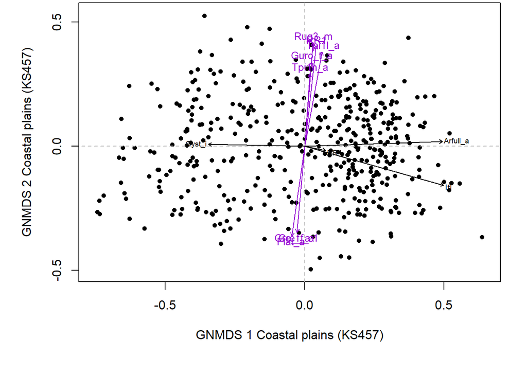

#### Complementary observations, axis 1 and 2:

- One OU belongs to OI Class 6 (big city). This is Id 2916 Oslo city, which occupies the extreme position along GNMDS axis 1.
- Agricultural intensity is associated with positive scores for GNMDS 1, and a certain degree of infrastructure (similar to IfI ≈ 4) is a prerequisite for amount/degree of agricultural land use intensity. The relationship between JI and IfI is slightly unimodal, that is, the agricultural land use intensity is strongest when the amount/degree of infrastructure is relatively high, but decreases again when the amount/degree of infrastructure is very high.
- The proportion of the area with deciduous forest (Arlov_a) is 0 at the outer parts of the archipelago (SN = 5; there are 156 OUs with Arlov = 0), but increases inward towards larger islands and on the mainland.
- The figure at the bottom left shows a clear (inverse) island size gradient, with a considerable variation in landscape characteristics related to the archipelago properties, first and foremost when the islands are smaller than 100 km2 (Oyst_i > 0.643). This opens the possibility that the complex gradient expressed on axis 1 is actually composed of two CLGs.
- Among the 69 OUs in KS lacking infrastructure (IfI = 0), all of the 56 as a largest island smaller than 1 km. Islands with significant infrastructure are generally much larger; one exception is Id 4038 which has Oyst_i = 0.8647 and IfI = 9.34. This polygon is located on the west and south part of Nøtterøy.
- It is noteworthy that the topographic variables give such a strong signal when there is so little topography variation within costal plains.

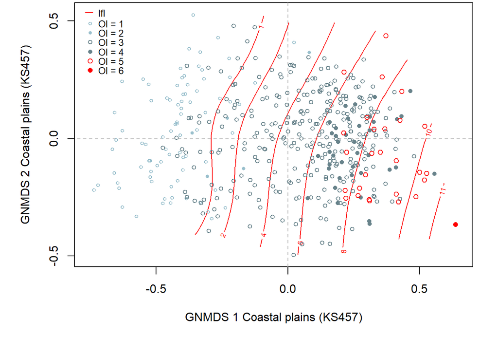

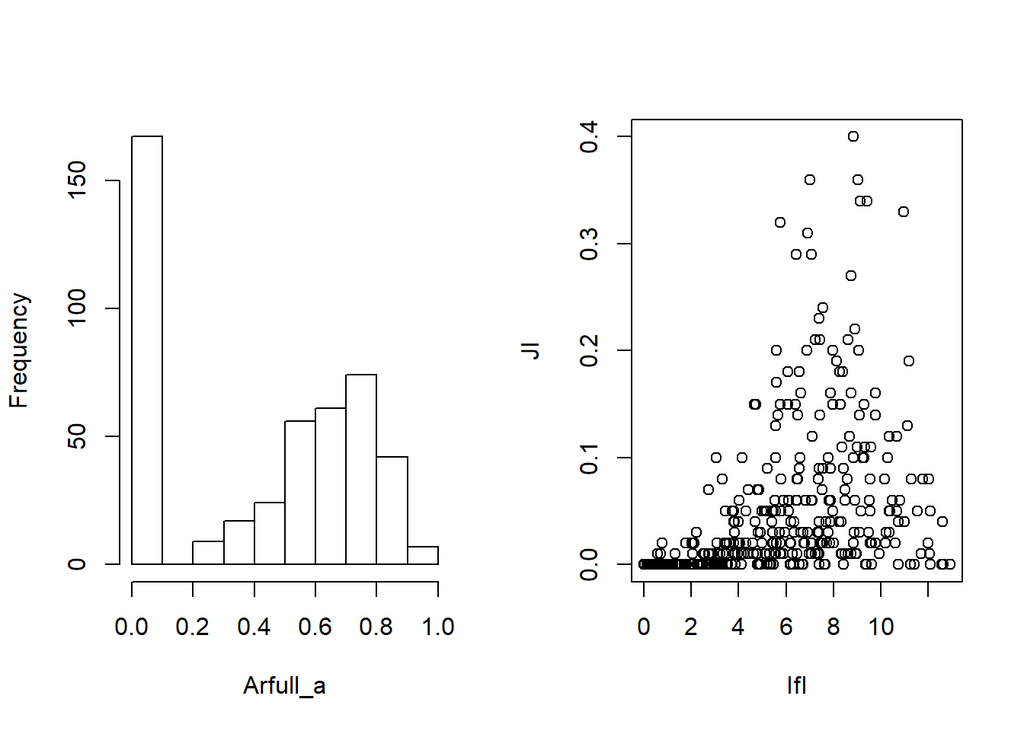

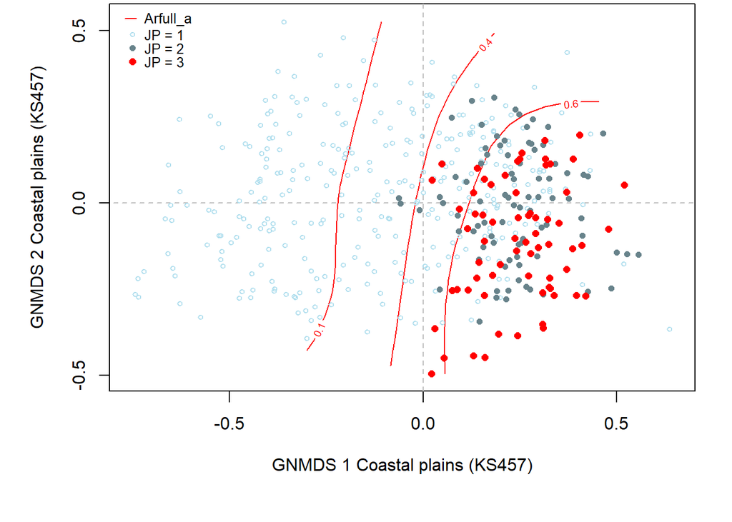

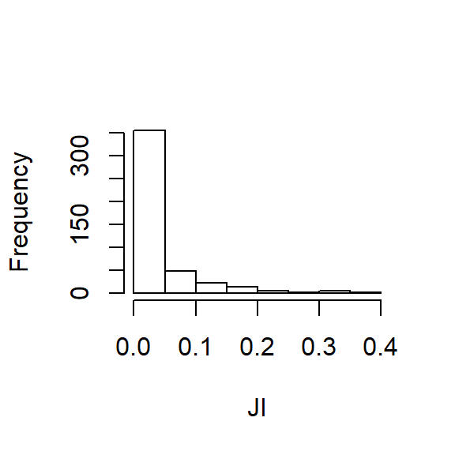

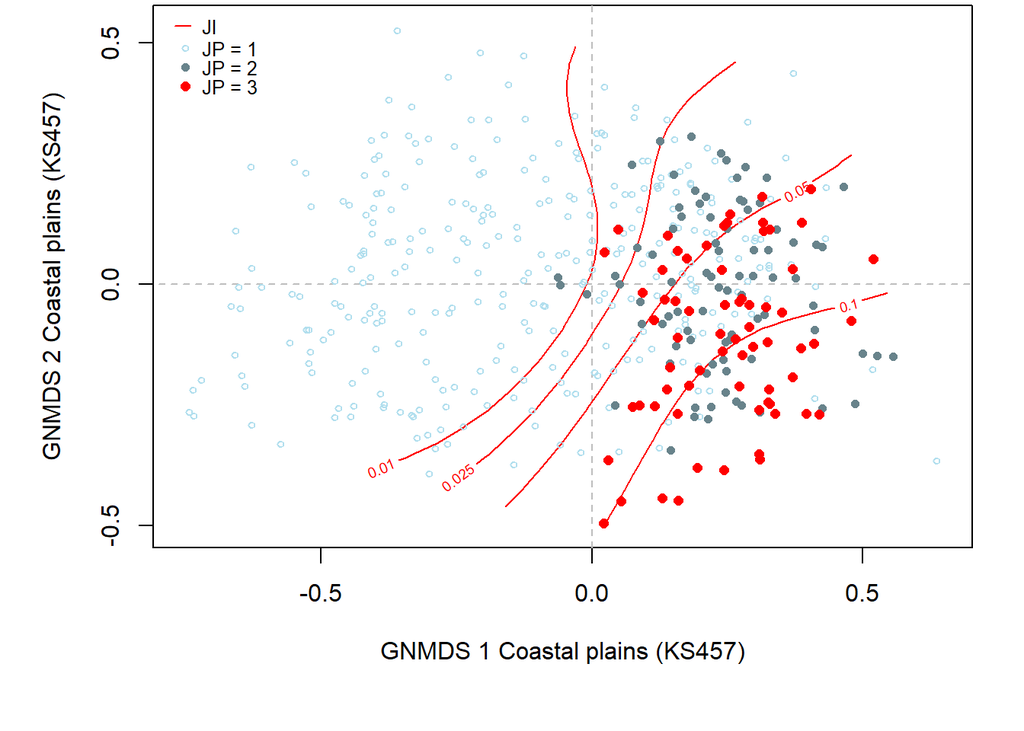

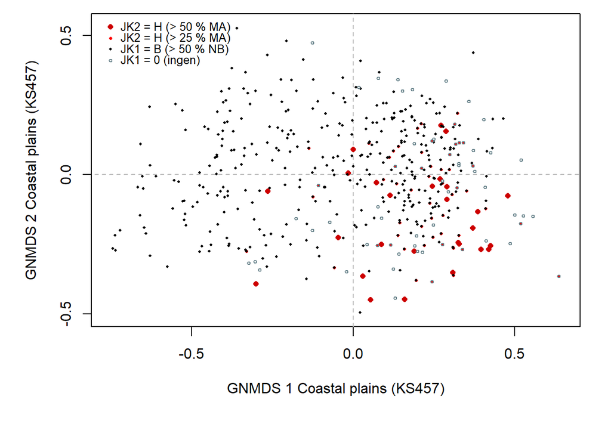

```r
##For JI med JP (akser 1 og 2)

hist(JI,  main = " ")
```

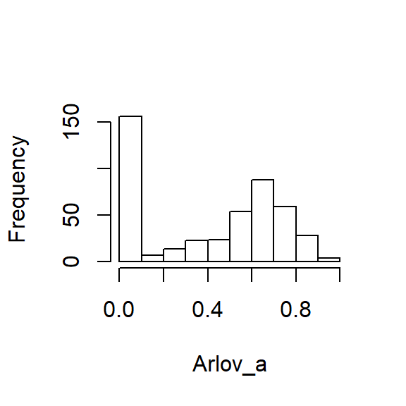

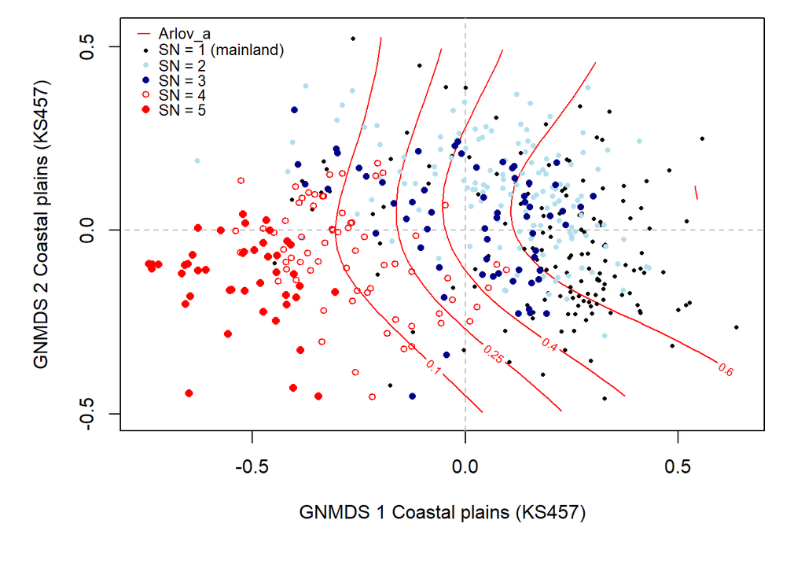

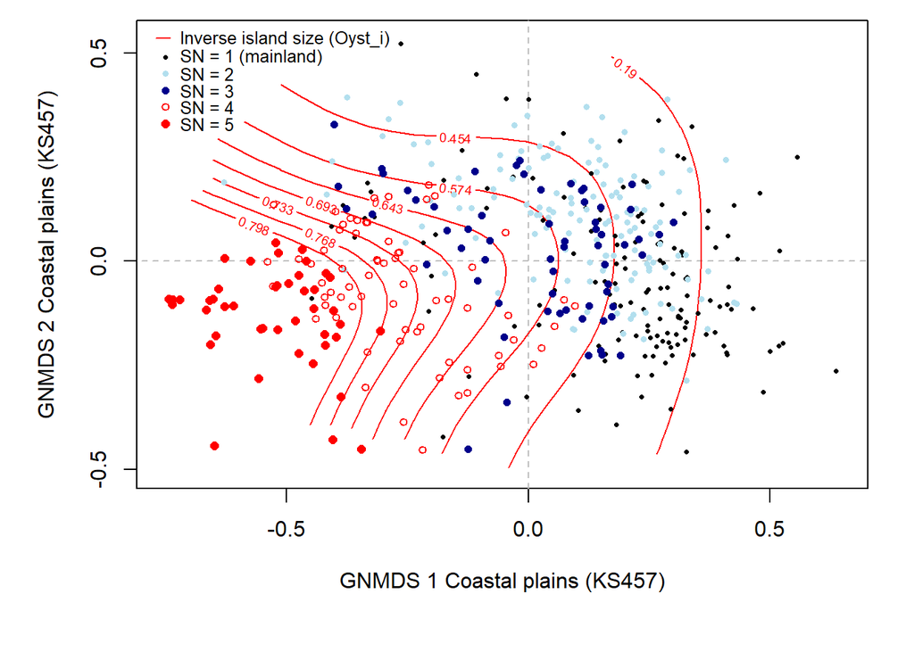

```r
##For Arlov_a (den enkeltvariabelen som er sterkest korrelert med akse 1) blant SN-relaterte variabler

hist(Arlov_a,  main = " ")
```

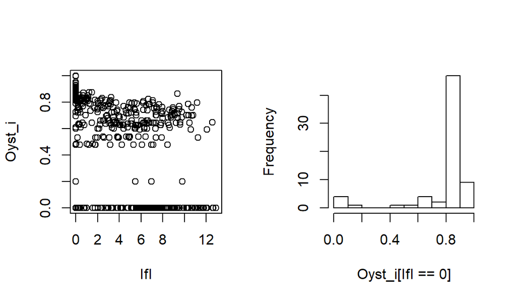

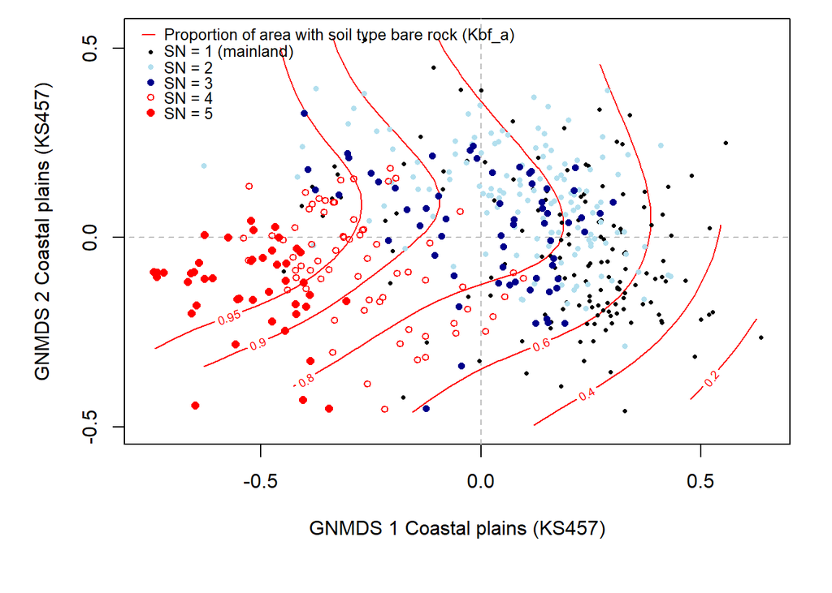

```r
par(mfrow=c(1,2))
plot(IfI,Oyst_i)
hist(Oyst_i[IfI==0], main= " ")
```

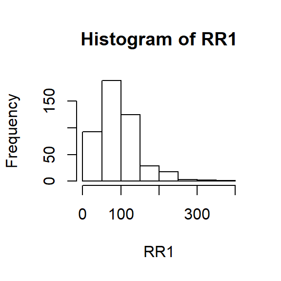

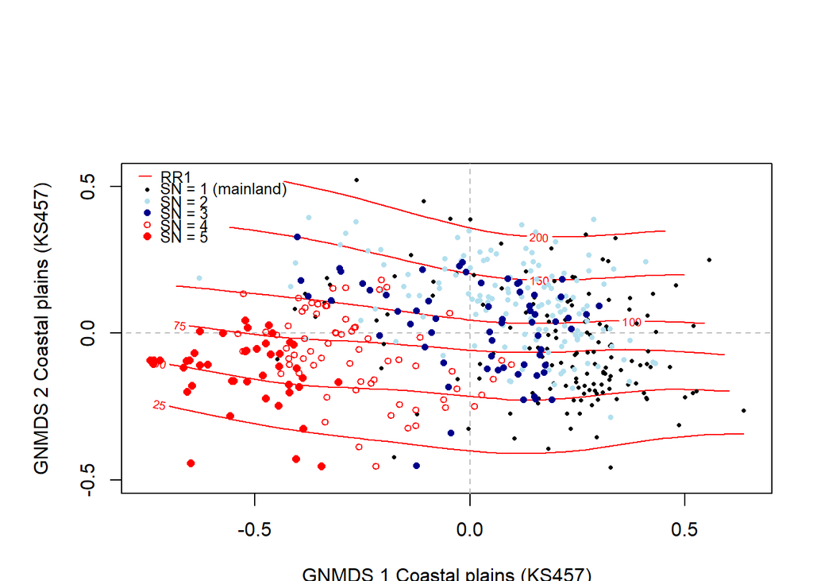

```r
#For RR1 (varierer fra 12 til 364) med SN

hist(RR1)
```

#### Tallfesting av KLG-kandidatenes relative viktighet ved variasjonsoppdelingsanalyse

```r
#Datasett: av

#Bestemmer total variasjon

vo0 <- rda(av~+1,scale=T)  #scale = T gjør at dataene blir sentrert og standardisert ved deling med SD
vo0
```

```
## Call: rda(formula = av ~ +1, scale = T)
##
##               Inertia Rank
## Total              84
## Unconstrained      84   84
## Inertia is correlations
##
## Eigenvalues for unconstrained axes:
##    PC1    PC2    PC3    PC4    PC5    PC6    PC7    PC8
## 13.689  9.256  6.466  5.348  3.291  3.036  2.548  2.308
## (Showing 8 of 84 unconstrained eigenvalues)
```

```r
voG1a <- rda(av~RR1,scale=T)
voG1a
```

```
## Call: rda(formula = av ~ RR1, scale = T)
##
##                Inertia Proportion Rank
## Total         84.00000    1.00000
## Constrained    7.36127    0.08763    1
## Unconstrained 76.63873    0.91237   84
## Inertia is correlations
##
## Eigenvalues for constrained axes:
##  RDA1
## 7.361
##
## Eigenvalues for unconstrained axes:
##    PC1    PC2    PC3    PC4    PC5    PC6    PC7    PC8
## 13.526  6.519  5.408  3.466  3.184  2.781  2.380  2.179
## (Showing 8 of 84 unconstrained eigenvalues)
```

```r
tvoG1a <- permutest(voG1a,permutations=9999)
tvoG1a
```

```
##
## Permutation test for rda under reduced model
##
## Permutation: free
## Number of permutations: 9999
##
## Model: rda(formula = av ~ RR1, scale = T)
## Permutation test for all constrained eigenvalues
##           Df Inertia      F Pr(>F)
## Model      1   7.361 43.703  1e-04 ***
## Residual 455  76.639
## ---
## Signif. codes:  0 '***' 0.001 '**' 0.01 '*' 0.05 '.' 0.1 ' ' 1
```

```r
voG1b <- rda(av~Crug9_m,scale=T)
voG1b
```

```
## Call: rda(formula = av ~ Crug9_m, scale = T)
##
##                Inertia Proportion Rank
## Total         84.00000    1.00000
## Constrained    7.70551    0.09173    1
## Unconstrained 76.29449    0.90827   83
## Inertia is correlations
##
## Eigenvalues for constrained axes:
##  RDA1
## 7.706
##
## Eigenvalues for unconstrained axes:
##    PC1    PC2    PC3    PC4    PC5    PC6    PC7    PC8
## 13.596  6.538  5.436  3.501  3.058  2.548  2.394  2.142
## (Showing 8 of 83 unconstrained eigenvalues)
```

```r
tvoG1b <- permutest(voG1b,permutations=9999)
tvoG1b
```

```
##
## Permutation test for rda under reduced model
##
## Permutation: free
## Number of permutations: 9999
##
## Model: rda(formula = av ~ Crug9_m, scale = T)
## Permutation test for all constrained eigenvalues
##           Df Inertia      F Pr(>F)
## Model      1   7.706 45.954  1e-04 ***
## Residual 455  76.294
## ---
## Signif. codes:  0 '***' 0.001 '**' 0.01 '*' 0.05 '.' 0.1 ' ' 1
```

voG1c <- rda(av~Rug3_m,scale=T) voG1c tvoG1c <- permutest(voG1c,permutations=9999) tvoG1c voG1d <- rda(av~Cr3_u_a,scale=T) voG1d tvoG1d <- permutest(voG1d,permutations=9999) tvoG1d voG1e <- rda(av~Flat_a,scale=T) voG1e tvoG1e <- permutest(voG1e,permutations=9999) tvoG1e voG1f <- rda(av~Tpi1l_a,scale=T) voG1f tvoG1f <- permutest(voG1f,permutations=9999) tvoG1f voG1g <- rda(av~Guro_t_a,scale=T) voG1g tvoG1g <- permutest(voG1g,permutations=9999) tvoG1g voG1h <- rda(av~Cre_f_a,scale=T) voG1h tvoG1h <- permutest(voG1h,permutations=9999) tvoG1h voG1i <- rda(av~Cre_b_a,scale=T) voG1i tvoG1i <- permutest(voG1i,permutations=9999) tvoG1i voG1j <- rda(av~Tpi1h_a,scale=T) voG1j tvoG1j <- permutest(voG1j,permutations=9999) tvoG1j voG1k <- rda(av~Steep_a,scale=T) voG1k tvoG1k <- permutest(voG1k,permutations=9999) tvoG1k voG1l <- rda(av~Crug3_m,scale=T) voG1l tvoG1l <- permutest(voG1l,permutations=9999) tvoG1l

```r
voG1ca <- rda(av~RR1+Condition(Rug3_m),scale=T)
voG1ca
```

```
## Call: rda(formula = av ~ RR1 + Condition(Rug3_m), scale = T)
##
##                Inertia Proportion Rank
## Total         84.00000    1.00000
## Conditional    8.40616    0.10007    1
## Constrained    1.82984    0.02178    1
## Unconstrained 73.76400    0.87814   83
## Inertia is correlations
##
## Eigenvalues for constrained axes:
##   RDA1
## 1.8298
##
## Eigenvalues for unconstrained axes:
##    PC1    PC2    PC3    PC4    PC5    PC6    PC7    PC8
## 13.518  6.346  4.960  3.184  2.908  2.496  2.220  2.085
## (Showing 8 of 83 unconstrained eigenvalues)
```

```r
tvoG1ca <- permutest(voG1ca,permutations=9999)
tvoG1ca
```

```
##
## Permutation test for rda under reduced model
##
## Permutation: free
## Number of permutations: 9999
##
## Model: rda(formula = av ~ RR1 + Condition(Rug3_m), scale = T)
## Permutation test for all constrained eigenvalues
##           Df Inertia      F Pr(>F)
## Model      1   1.830 11.262  1e-04 ***
## Residual 454  73.764
## ---
## Signif. codes:  0 '***' 0.001 '**' 0.01 '*' 0.05 '.' 0.1 ' ' 1
```

voG1cb <- rda(av~Crug9_m+Condition(Rug3_m),scale=T) voG1cb tvoG1cb <- permutest(voG1cb,permutations=9999) tvoG1cb

```r
voG1cd <- rda(av~Cr3_u_a+Condition(Rug3_m),scale=T)
voG1cd
```

```
## Call: rda(formula = av ~ Cr3_u_a + Condition(Rug3_m), scale = T)
##
##                Inertia Proportion Rank
## Total         84.00000    1.00000
## Conditional    8.40616    0.10007    1
## Constrained    1.35837    0.01617    1
## Unconstrained 74.23547    0.88376   82
## Inertia is correlations
##
## Eigenvalues for constrained axes:
##   RDA1
## 1.3584
##
## Eigenvalues for unconstrained axes:
##    PC1    PC2    PC3    PC4    PC5    PC6    PC7    PC8
## 13.519  6.464  4.968  3.494  3.035  2.552  2.218  2.094
## (Showing 8 of 82 unconstrained eigenvalues)
```

```r
tvoG1cd <- permutest(voG1cd,permutations=9999)
tvoG1cd
```

```
##
## Permutation test for rda under reduced model
##
## Permutation: free
## Number of permutations: 9999
##
## Model: rda(formula = av ~ Cr3_u_a + Condition(Rug3_m), scale = T)
## Permutation test for all constrained eigenvalues
##           Df Inertia      F Pr(>F)
## Model      1   1.358 8.3073  1e-04 ***
## Residual 454  74.235
## ---
## Signif. codes:  0 '***' 0.001 '**' 0.01 '*' 0.05 '.' 0.1 ' ' 1
```

voG1ce <- rda(av~Flat_a+Condition(Rug3_m),scale=T) voG1ce tvoG1ce <- permutest(voG1ce,permutations=9999) tvoG1ce voG1cf <- rda(av~Tpi1l_a+Condition(Rug3_m),scale=T) voG1cf tvoG1cf <- permutest(voG1cf,permutations=9999) tvoG1cf voG1cg <- rda(av~Guro_t_a+Condition(Rug3_m),scale=T) voG1cg tvoG1cg <- permutest(voG1cg,permutations=9999) tvoG1cg voG1ch <- rda(av~Cre_f_a+Condition(Rug3_m),scale=T) voG1ch tvoG1ch <- permutest(voG1ch,permutations=9999) tvoG1ch voG1ci <- rda(av~Cre_b_a+Condition(Rug3_m),scale=T) voG1ci tvoG1ci <- permutest(voG1ci,permutations=9999) tvoG1ci voG1cj <- rda(av~Tpi1h_a+Condition(Rug3_m),scale=T) voG1cj tvoG1cj <- permutest(voG1cj,permutatioks=9999) tvoG1cj voG1ck <- rda(av~Steep_a+Condition(Rug3_m),scale=T) voG1ck tvoG1ck <- permutest(voG1ck,permutations=9999) tvoG1ck voG1cl <- rda(av~Crug3_m+Condition(Rug3_m),scale=T) voG1cl tvoG1cl <- permutest(voG1cl,permutations=9999) tvoG1cl

voG1cja <- rda(av~RR1+Condition(Rug3_m+Tpi1h_a),scale=T) voG1cja tvoG1cja <- permutest(voG1cja,permutations=9999) tvoG1cja

voG1cjb <- rda(av~Crug9_m+Condition(Rug3_m+Tpi1h_a),scale=T) voG1cjb tvoG1cjb <- permutest(voG1cjb,permutations=9999) tvoG1cjb voG1cjd <- rda(av~Cr3_u_a+Condition(Rug3_m+Tpi1h_a),scale=T) voG1cjd tvoG1cjd <- permutest(voG1cjd,permutations=9999) tvoG1cjd voG1cje <- rda(av~Flat_a+Condition(Rug3_m+Tpi1h_a),scale=T) voG1cje tvoG1cje <- permutest(voG1cje,permutations=9999) tvoG1cje voG1cjf <- rda(av~Tpi1l_a+Condition(Rug3_m+Tpi1h_a),scale=T) voG1cjf tvoG1cjf <- permutest(voG1cjf,permutations=9999) tvoG1cjf voG1cjg <- rda(av~Guro_t_a+Condition(Rug3_m+Tpi1h_a),scale=T) voG1cjg tvoG1cjg <- permutest(voG1cjg,permutations=9999) tvoG1cjg voG1cjh <- rda(av~Cre_f_a+Condition(Rug3_m+Tpi1h_a),scale=T) voG1cjh tvoG1cjh <- permutest(voG1cjh,permutations=9999) tvoG1cjh voG1cji <- rda(av~Cre_b_a+Condition(Rug3_m+Tpi1h_a),scale=T) voG1cji tvoG1cji <- permutest(voG1cji,permutations=9999) tvoG1cji voG1cjl <- rda(av~Crug3_m+Condition(Rug3_m+Tpi1h_a),scale=T) voG1cjl tvoG1cjl <- permutest(voG1cjl,permutations=9999) tvoG1cjl

voG1cjhf <- rda(av~Tpi1l_a+Condition(Rug3_m+Tpi1h_a+Cre_f_a),scale=T) voG1cjhf tvoG1cjhf <- permutest(voG1cjhf,permutations=9999) tvoG1cjhf voG1cjhk <- rda(av~Crug3_m+Condition(Rug3_m+Tpi1h_a+Cre_f_a),scale=T) voG1cjhk tvoG1cjhk <- permutest(voG1cjhk,permutations=99) tvoG1cjhk

voG2a <- rda(av~Oyst_i,scale=T) voG2a tvoG2a <- permutest(voG2a,permutations=9999) tvoG2a voG2b <- rda(av~Land_a,scale=T) voG2b tvoG2b <- permutest(voG2b,permutations=9999) tvoG2b voG2c <- rda(av~R_net_a,scale=T) voG2c tvoG2c <- permutest(voG2c,permutations=9999) tvoG2c voG2d <- rda(av~Kbf_a,scale=T) voG2d tvoG2d <- permutest(voG2d,permutations=9999) tvoG2d voG2e <- rda(av~Ekspve_a,scale=T) voG2e tvoG2e <- permutest(voG2e,permutations=9999) tvoG2e voG2f <- rda(av~Stromn_a,scale=T) voG2f tvoG2f <- permutest(voG2f,permutations=9999) tvoG2f

voG2ca <- rda(av~Oyst_i+Condition(R_net_a),scale=T) voG2ca tvoG2ca <- permutest(voG2ca,permutations=99) tvoG2ca voG2cb <- rda(av~Land_a+Condition(R_net_a),scale=T) voG2cb tvoG2cb <- permutest(voG2cb,permutations=99) tvoG2cb voG2cd <- rda(av~Kbf_a+Condition(R_net_a),scale=T) voG2cd tvoG2cd <- permutest(voG2cd,permutations=99) tvoG2cd voG2ce <- rda(av~Ekspve_a+Condition(R_net_a),scale=T) voG2ce tvoG2ce <- permutest(voG2ce,permutations=99) tvoG2ce voG2cf <- rda(av~Stromn_a+Condition(R_net_a),scale=T) voG2cf tvoG2cf <- permutest(voG2cf,permutations=99) tvoG2cf

voG2cea <- rda(av~Oyst_i+Condition(R_net_a+Ekspve_a),scale=T) voG2cea tvoG2cea <- permutest(voG2cea,permutations=99) tvoG2cea voG2ced <- rda(av~Kbf_a+Condition(R_net_a+Ekspve_a),scale=T) voG2ced tvoG2ced <- permutest(voG2ced,permutations=99) tvoG2ced voG2cef <- rda(av~Stromn_a+Condition(R_net_a+Ekspve_a),scale=T) voG2cef tvoG2cef <- permutest(voG2cef,permutations=99) tvoG2cef

voG2cead <- rda(av~Kbf_a+Condition(R_net_a+Ekspve_a+Oyst_i),scale=T) voG2cead tvoG2cead <- permutest(voG2cead,permutations=99) tvoG2cead voG2ceaf <- rda(av~Stromn_a+Condition(R_net_a+Ekspve_a+Oyst_i),scale=T) voG2ceaf tvoG2ceaf <- permutest(voG2ceaf,permutations=99) tvoG2ceaf

voG3a <- rda(av~Inns_s,scale=T) voG3a tvoG3a <- permutest(voG3a,permutations=9999) tvoG3a voG3b <- rda(av~II,scale=T) voG3b tvoG3b <- permutest(voG3b,permutations=9999) tvoG3b voG3c <- rda(av~Dislake,scale=T) voG3c tvoG3c <- permutest(voG3c,permutations=9999) tvoG3c voG3d <- rda(av~MI,scale=T) voG3d tvoG3d <- permutest(voG3d,permutations=9999) tvoG3d voG3e <- rda(av~Dismire,scale=T) voG3e tvoG3e <- permutest(voG3e,permutations=9999) tvoG3e

voG3ea <- rda(av~Inns_s+Condition(Dismire),scale=T) voG3ea tvoG3ea <- permutest(voG3ea,permutations=99) tvoG3ea voG3eb <- rda(av~II+Condition(Dismire),scale=T) voG3eb tvoG3eb <- permutest(voG3eb,permutations=99) tvoG3eb voG3ec <- rda(av~Dislake+Condition(Dismire),scale=T) voG3ec tvoG3ec <- permutest(voG3ec,permutations=99) tvoG3ec voG3ed <- rda(av~MI+Condition(Dismire),scale=T) voG3ed tvoG3ed <- permutest(voG3ed,permutations=99) tvoG3ed

voG3eac <- rda(av~Dislake+Condition(Dismire+Inns_s),scale=T) voG3eac tvoG3eac <- permutest(voG3eac,permutations=99) tvoG3eac

voG4a <- rda(av~C_kk_a,scale=T) voG4a tvoG4a <- permutest(voG4a,permutations=99) tvoG4a voG4b <- rda(av~Ccom_m,scale=T) voG4b tvoG4b <- permutest(voG4b,permutations=99) tvoG4b voG4c <- rda(av~Maro_s,scale=T) voG4c tvoG4c <- permutest(voG4c,permutations=99) tvoG4c voG4d <- rda(av~Bplu_a,scale=T) voG4d tvoG4d <- permutest(voG4d,permutations=99) tvoG4d voG4e <- rda(av~Kmar_a,scale=T) voG4e tvoG4e <- permutest(voG4e,permutations=99) tvoG4e

voG4ba <- rda(av~C_kk_a+Condition(Ccom_m),scale=T) voG4ba tvoG4ba <- permutest(voG4ba,permutations=99) tvoG4ba voG4bc <- rda(av~Maro_s+Condition(Ccom_m),scale=T) voG4bc tvoG4bc <- permutest(voG4bc,permutations=99) tvoG4bc voG4bd <- rda(av~Bplu_a+Condition(Ccom_m),scale=T) voG4bd tvoG4bd <- permutest(voG4bd,permutations=99) tvoG4bd voG4be <- rda(av~Kmar_a+Condition(Ccom_m),scale=T) voG4be tvoG4be <- permutest(voG4be,permutations=99) tvoG4be

voG4bca <- rda(av~C_kk_a+Condition(Ccom_m+Maro_s),scale=T) voG4bca tvoG4bca <- permutest(voG4bca,permutations=99) tvoG4bca voG4bcd <- rda(av~Bplu_a+Condition(Ccom_m+Maro_s),scale=T) voG4bcd tvoG4bcd <- permutest(voG4bcd,permutations=99) tvoG4bcd

voG5 <- rda(av~JK1,scale=T) voG5 tvoG5 <- permutest(voG5,permutations=99) tvoG5

voG6 <- rda(av~JK2,scale=T) voG6 tvoG6 <- permutest(voG6,permutations=99) tvoG6

voG7a <- rda(av~Kbf_a,scale=T) voG7a tvoG7a <- permutest(voG7a,permutations=99) tvoG7a voG7b <- rda(av~Kmar_a,scale=T) voG7b tvoG7b <- permutest(voG7b,permutations=99) tvoG7b voG7ba <- rda(av~Kbf_a+Condition(Kmar_a),scale=T) voG7ba tvoG7ba <- permutest(voG7ba,permutations=99) tvoG7ba

voU1a <- rda(av~Arlov_a,scale=T) voU1a tvoU1a <- permutest(voU1a,permutations=99) tvoU1a voU1b <- rda(av~Arbar_a,scale=T) voU1b tvoU1b <- permutest(voU1b,permutations=99) tvoU1b voU1c <- rda(av~Arbla_a,scale=T) voU1c tvoU1c <- permutest(voU1c,permutations=99) tvoU1c

voU1ab <- rda(av~Arbar_a+Condition(Arlov_a),scale=T) voU1ab tvoU1ab <- permutest(voU1ab,permutations=99) tvoU1ab voU1ac <- rda(av~Arbla_a+Condition(Arlov_a),scale=T) voU1ac tvoU1ac <- permutest(voU1ac,permutations=99) tvoU1ac

voU1acb <- rda(av~Arbar_a+Condition(Arlov_a+Arbla_a),scale=T) voU1acb tvoU1acb <- permutest(voU1acb,permutations=99) tvoU1acb

voU2a <- rda(av~Sn_torr,scale=T) voU2a tvoU2a <- permutest(voU2a,permutations=99) tvoU2a voU2b <- rda(av~Sn_frisk,scale=T) voU2b tvoU2b <- permutest(voU2b,permutations=99) tvoU2b voU2c <- rda(av~Sn_flekk,scale=T) voU2c tvoU2c <- permutest(voU2c,permutations=99) tvoU2c voU2d <- rda(av~Bohei_a,scale=T) voU2d tvoU2d <- permutest(voU2d,permutations=99) tvoU2d voU2e <- rda(av~Araaf_a,scale=T) voU2e tvoU2e <- permutest(voU2e,permutations=99) tvoU2e

voU2da <- rda(av~Sn_torr+Condition(Bohei_a),scale=T) voU2da tvoU2da <- permutest(voU2da,permutations=99) tvoU2da voU2db <- rda(av~Sn_frisk+Condition(Bohei_a),scale=T) voU2db tvoU2db <- permutest(voU2db,permutations=99) tvoU2db voU2dc <- rda(av~Sn_flekk+Condition(Bohei_a),scale=T) voU2dc tvoU2dc <- permutest(voU2dc,permutations=99) tvoU2dc voU2de <- rda(av~Araaf_a+Condition(Bohei_a),scale=T) voU2de tvoU2de <- permutest(voU2de,permutations=99) tvoU2de

voU2dca <- rda(av~Sn_torr+Condition(Bohei_a+Sn_flekk),scale=T) voU2dca tvoU2dca <- permutest(voU2dca,permutations=99) tvoU2dca voU2dcb <- rda(av~Sn_frisk+Condition(Bohei_a+Sn_flekk),scale=T) voU2dcb tvoU2dcb <- permutest(voU2dcb,permutations=99) tvoU2dcb voU2dce <- rda(av~Araaf_a+Condition(Bohei_a+Sn_flekk),scale=T) voU2dce tvoU2dce <- permutest(voU2dce,permutations=99) tvoU2dce

voA1a <- rda(av~IfI,scale=T) voA1a tvoA1a <- permutest(voA1a,permutations=9999) tvoA1a voA1b <- rda(av~Gab_a,scale=T) voA1b tvoA1b <- permutest(voA1b,permutations=9999) tvoA1b voA1c <- rda(av~Lled_a,scale=T) voA1c tvoA1c <- permutest(voA1c,permutations=9999) tvoA1c voA1d <- rda(av~Vei_b_a,scale=T) voA1d tvoA1d <- permutest(voA1d,permutations=9999) tvoA1d voA1e <- rda(av~Sefr_a,scale=T) voA1e tvoA1e <- permutest(voA1e,permutations=9999) tvoA1e voA1f <- rda(av~Cul_a_s,scale=T) voA1f tvoA1f <- permutest(voA1f,permutations=9999) tvoA1f voA1g <- rda(av~Abygg_a,scale=T) voA1g tvoA1g <- permutest(voA1g,permutations=9999) tvoA1g voA1h <- rda(av~Gab_nae,scale=T) voA1h tvoA1h <- permutest(voA1h,permutations=99) tvoA1h

voA1ba <- rda(av~IfI+Condition(Gab_a),scale=T) voA1ba tvoA1ba <- permutest(voA1ba,permutations=9999) tvoA1ba voA1bc <- rda(av~Lled_a+Condition(Gab_a),scale=T) voA1bc tvoA1bc <- permutest(voA1bc,permutations=9999) tvoA1bc voA1bd <- rda(av~Vei_b_a+Condition(Gab_a),scale=T) voA1bd tvoA1bd <- permutest(voA1bd,permutations=9999) tvoA1bd voA1be <- rda(av~Sefr_a+Condition(Gab_a),scale=T) voA1be tvoA1be <- permutest(voA1be,permutations=9999) tvoA1be voA1bf <- rda(av~Cul_a_s+Condition(Gab_a),scale=T) voA1bf tvoA1bf <- permutest(voA1bf,permutations=9999) tvoA1bf voA1bg <- rda(av~Abygg_a+Condition(Gab_a),scale=T) voA1bg tvoA1bg <- permutest(voA1bg,permutations=9999) tvoA1bg voA1bh <- rda(av~Gab_nae+Condition(Gab_a),scale=T) voA1bh tvoA1bh <- permutest(voA1bh,permutations=9999) tvoA1bh

voA1bag <- rda(av~Abygg_a+Condition(Gab_a+IfI),scale=T) voA1bag tvoA1bag <- permutest(voA1bag,permutations=9999) tvoA1bag voA1bah <- rda(av~Gab_nae+Condition(Gab_a+IfI),scale=T) voA1bah tvoA1bah <- permutest(voA1bah,permutations=9999) tvoA1bah

voA2a <- rda(av~Arfull_a,scale=T) voA2a tvoA2a <- permutest(voA2a,permutations=99) tvoA2a voA2b <- rda(av~JI,scale=T) voA2b tvoA2b <- permutest(voA2c,permutations=99) tvoA2b voA2c <- rda(av~Arover_a,scale=T) voA2c tvoA2c <- permutest(voA2c,permutations=99) tvoA2c

voA2ab <- rda(av~JI+Condition(Arfull_a),scale=T) voA2ab tvoA2ab <- permutest(voA2ab,permutations=99) tvoA2ab voA2ac <- rda(av~Arover_a+Condition(Arfull_a),scale=T) voA2ac tvoA2ac <- permutest(voA2ac,permutations=99) tvoA2ac

voG2G1 <- rda(av~Rug3_m+Tpi1h_a+Condition(R_net_a+Ekspve_a+Oyst_i),scale=T) voG2G1 tvoG2G1 <- permutest(voG2G1,permutations=99) tvoG2G1 voG2G3 <- rda(av~Dismire+Inns_s+Dislake+Condition(R_net_a+Ekspve_a+Oyst_i),scale=T) voG2G3 tvoG2G3 <- permutest(voG2G3,permutations=99) tvoG2G3 voG2G4 <- rda(av~Ccom_m + Maro_s+Condition(R_net_a+Ekspve_a+Oyst_i),scale=T) voG2G4 tvoG2G4 <- permutest(voG2G4,permutations=99) tvoG2G4 voG2G5 <- rda(av~Kbf_a+Kmar_a+Condition(R_net_a+Ekspve_a+Oyst_i),scale=T) voG2G5 tvoG2G5 <- permutest(voG2G5,permutations=99) tvoG2G5

voG2G1G3 <- rda(av~Dismire+Inns_s + Dislake+Condition(R_net_a+Ekspve_a+Oyst_i+Rug3_m+Tpi1h_a),scale=T) voG2G1G3 tvoG2G1G3 <- permutest(voG2G1G3,permutations=99) tvoG2G1G3 voG2G1G4 <- rda(av~Ccom_m + Maro_s+Condition(R_net_a+Ekspve_a+Oyst_i+Rug3_m+Tpi1h_a),scale=T) voG2G1G4 tvoG2G1G4 <- permutest(voG2G1G4,permutations=99) tvoG2G1G4

voG2G1G3G4 <- rda(av~Ccom_m + Maro_s+Condition(R_net_a+Ekspve_a+Oyst_i+Rug3_m+Tpi1h_a+Dismire+Inns_s + Dislake),scale=T) voG2G1G3G4 tvoG2G1G3G4 <- permutest(voG2G1G3G4,permutations=99) tvoG2G1G3G4

voGU1 <- rda(av~Arlov_a+Arbla_a+Condition(R_net_a+Ekspve_a+Oyst_i+Rug3_m+Tpi1h_a+Dismire+Inns_s + Dislake),scale=T) voGU1 tvoGU1 <- permutest(voGU1,permutations=99) tvoGU1 voGU2 <- rda(av~Bohei_a+Sn_flekk+Condition(R_net_a+Ekspve_a+Oyst_i+Rug3_m+Tpi1h_a+Dismire+Inns_s + Dislake),scale=T) voGU2 tvoGU2 <- permutest(voGU2,permutations=99) tvoGU2

voGU1U2 <- rda(av~Bohei_a+Sn_flekk+Condition(Arlov_a+Arbla_a+R_net_a+Ekspve_a+Oyst_i+Rug3_m+Tpi1h_a+Dismire+Inns_s + Dislake),scale=T) voGU1U2 tvoGU1U2 <- permutest(voGU1U2,permutations=99) tvoGU1U2

```r
voGUA1 <- rda(av~IfI+Gab_a+Condition(Arlov_a+Arbla_a+R_net_a+Ekspve_a+Oyst_i+Rug3_m+Tpi1h_a+Dismire+Inns_s + Dislake),scale=T)
voGUA1
```

```
## Call: rda(formula = av ~ IfI + Gab_a + Condition(Arlov_a + Arbla_a
## + R_net_a + Ekspve_a + Oyst_i + Rug3_m + Tpi1h_a + Dismire +
## Inns_s + Dislake), scale = T)
##
##                Inertia Proportion Rank
## Total         84.00000    1.00000
## Conditional   35.69094    0.42489   10
## Constrained    3.37974    0.04023    2
## Unconstrained 44.92933    0.53487   73
## Inertia is correlations
##
## Eigenvalues for constrained axes:
##   RDA1   RDA2
## 2.7001 0.6797
##
## Eigenvalues for unconstrained axes:
##    PC1    PC2    PC3    PC4    PC5    PC6    PC7    PC8
## 2.9131 2.4753 2.1274 2.0773 1.8286 1.5984 1.5089 1.4163
## (Showing 8 of 73 unconstrained eigenvalues)
```

```r
tvoGUA1 <- permutest(voGUA1,permutations=99)
tvoGUA1
```

```
##
## Permutation test for rda under reduced model
##
## Permutation: free
## Number of permutations: 99
##
## Model: rda(formula = av ~ IfI + Gab_a + Condition(Arlov_a +
## Arbla_a + R_net_a + Ekspve_a + Oyst_i + Rug3_m + Tpi1h_a + Dismire
## + Inns_s + Dislake), scale = T)
## Permutation test for all constrained eigenvalues
##           Df Inertia    F Pr(>F)
## Model      2   3.380 16.7   0.01 **
## Residual 444  44.929
## ---
## Signif. codes:  0 '***' 0.001 '**' 0.01 '*' 0.05 '.' 0.1 ' ' 1
```

voGUA2 <- rda(av~Arfull_a+Arover_a+Condition(Arlov_a+Arbla_a+R_net_a+Ekspve_a+Oyst_i+Rug3_m+Tpi1h_a+Dismire+Inns_s + Dislake),scale=T) voGUA2 tvoGUA2 <- permutest(voGUA2,permutations=99) tvoGUA2

#### Finner prim?rn?kkelvariabler for identifiserte KLG ved RDA

#Skript for ? finne ortogonale prim?rn?kkelvariabler (rONV’er) i ei n?kkelvariabelgruppe

#Om n?dvendig: importerer relevante rPNV’er

#dta_pnv <- read-table(“clipboard”,header=T) #attach(dta_pnv)

#VE for 1 .akse i RDA’er gir VA(PNV)

```r
RDA_IYK <- rda(av~R_net_a+Ekspve_a  + Oyst_i,scale=T)
```

RDA_RE <- rda(av~Rug3_m + Tpi1h_a,scale=T) RDA_VP <- rda(av~Dismire+Inns_s + Dislake,scale=T) RDA_SkP <- rda(av~Arlov_a + Arbla_a,scale=T) RDA_OI <- rda(av~IfI+Gab_a,scale=T)

#EV for RDA 1 gir VE for PNV

```r
summary(RDA_IYK)$cont
```

```
## $importance
## Importance of components:
##                         RDA1    RDA2    RDA3    PC1     PC2     PC3
## Eigenvalue            9.7305 2.76446 1.98826 9.2177 6.20919 5.37765
## Proportion Explained  0.1158 0.03291 0.02367 0.1097 0.07392 0.06402
## Cumulative Proportion 0.1158 0.14875 0.17242 0.2822 0.35607 0.42009
##                           PC4     PC5     PC6     PC7     PC8     PC9
## Eigenvalue            3.60081 2.85410 2.67206 2.29847 2.02309 1.81127
## Proportion Explained  0.04287 0.03398 0.03181 0.02736 0.02408 0.02156
## Cumulative Proportion 0.46296 0.49694 0.52875 0.55611 0.58019 0.60176
##                          PC10    PC11   PC12    PC13    PC14   PC15
## Eigenvalue            1.65158 1.47373 1.3609 1.30749 1.17025 1.1507
## Proportion Explained  0.01966 0.01754 0.0162 0.01557 0.01393 0.0137
## Cumulative Proportion 0.62142 0.63896 0.6552 0.67073 0.68466 0.6984
##                          PC16    PC17    PC18    PC19    PC20   PC21
## Eigenvalue            1.09643 1.08596 1.04510 0.96740 0.94303 0.9237
## Proportion Explained  0.01305 0.01293 0.01244 0.01152 0.01123 0.0110
## Cumulative Proportion 0.71141 0.72434 0.73678 0.74830 0.75953 0.7705
##                          PC22     PC23     PC24     PC25     PC26     PC27
## Eigenvalue            0.87212 0.833649 0.799233 0.776699 0.728329 0.716961
## Proportion Explained  0.01038 0.009924 0.009515 0.009246 0.008671 0.008535
## Cumulative Proportion 0.78090 0.790829 0.800344 0.809590 0.818261 0.826796
##                           PC28     PC29    PC30     PC31     PC32     PC33
## Eigenvalue            0.684749 0.658644 0.59054 0.571496 0.546679 0.535149
## Proportion Explained  0.008152 0.007841 0.00703 0.006804 0.006508 0.006371
## Cumulative Proportion 0.834948 0.842789 0.84982 0.856623 0.863131 0.869501
##                           PC34     PC35     PC36     PC37     PC38
## Eigenvalue            0.527408 0.495545 0.475778 0.469020 0.457880
## Proportion Explained  0.006279 0.005899 0.005664 0.005584 0.005451
## Cumulative Proportion 0.875780 0.881679 0.887343 0.892927 0.898378
##                           PC39     PC40     PC41     PC42     PC43
## Eigenvalue            0.441580 0.432879 0.404096 0.394041 0.379898
## Proportion Explained  0.005257 0.005153 0.004811 0.004691 0.004523
## Cumulative Proportion 0.903635 0.908788 0.913599 0.918290 0.922812
##                           PC44     PC45     PC46     PC47     PC48
## Eigenvalue            0.358335 0.338774 0.333128 0.325799 0.311593
## Proportion Explained  0.004266 0.004033 0.003966 0.003879 0.003709
## Cumulative Proportion 0.927078 0.931111 0.935077 0.938956 0.942665
##                           PC49     PC50     PC51     PC52     PC53    PC54
## Eigenvalue            0.286381 0.283246 0.270627 0.260274 0.251770 0.24440
## Proportion Explained  0.003409 0.003372 0.003222 0.003098 0.002997 0.00291
## Cumulative Proportion 0.946074 0.949446 0.952668 0.955767 0.958764 0.96167
##                           PC55     PC56     PC57     PC58     PC59
## Eigenvalue            0.230436 0.221970 0.215351 0.203739 0.194790
## Proportion Explained  0.002743 0.002642 0.002564 0.002425 0.002319
## Cumulative Proportion 0.964417 0.967059 0.969623 0.972048 0.974367
##                           PC60    PC61     PC62     PC63     PC64     PC65
## Eigenvalue            0.181163 0.16634 0.162910 0.155993 0.149609 0.139574
## Proportion Explained  0.002157 0.00198 0.001939 0.001857 0.001781 0.001662
## Cumulative Proportion 0.976524 0.97850 0.980444 0.982301 0.984082 0.985743
##                          PC66     PC67     PC68     PC69     PC70     PC71
## Eigenvalue            0.13268 0.127307 0.124466 0.112150 0.102674 0.092009
## Proportion Explained  0.00158 0.001516 0.001482 0.001335 0.001222 0.001095
## Cumulative Proportion 0.98732 0.988838 0.990320 0.991655 0.992878 0.993973
##                            PC72      PC73      PC74      PC75      PC76
## Eigenvalue            0.0834375 0.0773108 0.0696833 0.0648536 0.0599590
## Proportion Explained  0.0009933 0.0009204 0.0008296 0.0007721 0.0007138
## Cumulative Proportion 0.9949663 0.9958867 0.9967162 0.9974883 0.9982021
##                            PC77      PC78      PC79      PC80      PC81
## Eigenvalue            0.0519664 0.0374154 0.0267063 0.0200610 0.0148743
## Proportion Explained  0.0006186 0.0004454 0.0003179 0.0002388 0.0001771
## Cumulative Proportion 0.9988207 0.9992662 0.9995841 0.9998229 1.0000000
```

summary(RDA_RE)$cont summary(RDA_VP)$cont summary(RDA_SkP)$cont summary(RDA_OI)$cont

```r
#Finner oPNV'er

oRDA_IYK <- rda(av~R_net_a+Ekspve_a  + Oyst_i,scale=T)
oRDA_RE <- rda(av~Rug3_m + Tpi1h_a+Condition(R_net_a+Ekspve_a  + Oyst_i),scale=T)
oRDA_VP <- rda(av~Dismire+Inns_s + Dislake+Condition(R_net_a+Ekspve_a  + Oyst_i +Rug3_m + Tpi1h_a),scale=T)
oRDA_SkP <- rda(av~Arlov_a + Arbla_a+Condition(Dismire+Inns_s + Dislake+R_net_a+Ekspve_a  + Oyst_i +Rug3_m + Tpi1h_a),scale=T)
oRDA_OI <- rda(av~IfI+Gab_a+Condition(Arlov_a + Arbla_a+Dismire+Inns_s + Dislake+R_net_a+Ekspve_a  + Oyst_i + Rug3_m + Tpi1h_a),scale=T)
```

```r
summary(oRDA_IYK)$cont  #gir egenverdien for RDA-akse 1
```

```
## $importance
## Importance of components:
##                         RDA1    RDA2    RDA3    PC1     PC2     PC3
## Eigenvalue            9.7305 2.76446 1.98826 9.2177 6.20919 5.37765
## Proportion Explained  0.1158 0.03291 0.02367 0.1097 0.07392 0.06402
## Cumulative Proportion 0.1158 0.14875 0.17242 0.2822 0.35607 0.42009
##                           PC4     PC5     PC6     PC7     PC8     PC9
## Eigenvalue            3.60081 2.85410 2.67206 2.29847 2.02309 1.81127
## Proportion Explained  0.04287 0.03398 0.03181 0.02736 0.02408 0.02156
## Cumulative Proportion 0.46296 0.49694 0.52875 0.55611 0.58019 0.60176
##                          PC10    PC11   PC12    PC13    PC14   PC15
## Eigenvalue            1.65158 1.47373 1.3609 1.30749 1.17025 1.1507
## Proportion Explained  0.01966 0.01754 0.0162 0.01557 0.01393 0.0137
## Cumulative Proportion 0.62142 0.63896 0.6552 0.67073 0.68466 0.6984
##                          PC16    PC17    PC18    PC19    PC20   PC21
## Eigenvalue            1.09643 1.08596 1.04510 0.96740 0.94303 0.9237
## Proportion Explained  0.01305 0.01293 0.01244 0.01152 0.01123 0.0110
## Cumulative Proportion 0.71141 0.72434 0.73678 0.74830 0.75953 0.7705
##                          PC22     PC23     PC24     PC25     PC26     PC27
## Eigenvalue            0.87212 0.833649 0.799233 0.776699 0.728329 0.716961
## Proportion Explained  0.01038 0.009924 0.009515 0.009246 0.008671 0.008535
## Cumulative Proportion 0.78090 0.790829 0.800344 0.809590 0.818261 0.826796
##                           PC28     PC29    PC30     PC31     PC32     PC33
## Eigenvalue            0.684749 0.658644 0.59054 0.571496 0.546679 0.535149
## Proportion Explained  0.008152 0.007841 0.00703 0.006804 0.006508 0.006371
## Cumulative Proportion 0.834948 0.842789 0.84982 0.856623 0.863131 0.869501
##                           PC34     PC35     PC36     PC37     PC38
## Eigenvalue            0.527408 0.495545 0.475778 0.469020 0.457880
## Proportion Explained  0.006279 0.005899 0.005664 0.005584 0.005451
## Cumulative Proportion 0.875780 0.881679 0.887343 0.892927 0.898378
##                           PC39     PC40     PC41     PC42     PC43
## Eigenvalue            0.441580 0.432879 0.404096 0.394041 0.379898
## Proportion Explained  0.005257 0.005153 0.004811 0.004691 0.004523
## Cumulative Proportion 0.903635 0.908788 0.913599 0.918290 0.922812
##                           PC44     PC45     PC46     PC47     PC48
## Eigenvalue            0.358335 0.338774 0.333128 0.325799 0.311593
## Proportion Explained  0.004266 0.004033 0.003966 0.003879 0.003709
## Cumulative Proportion 0.927078 0.931111 0.935077 0.938956 0.942665
##                           PC49     PC50     PC51     PC52     PC53    PC54
## Eigenvalue            0.286381 0.283246 0.270627 0.260274 0.251770 0.24440
## Proportion Explained  0.003409 0.003372 0.003222 0.003098 0.002997 0.00291
## Cumulative Proportion 0.946074 0.949446 0.952668 0.955767 0.958764 0.96167
##                           PC55     PC56     PC57     PC58     PC59
## Eigenvalue            0.230436 0.221970 0.215351 0.203739 0.194790
## Proportion Explained  0.002743 0.002642 0.002564 0.002425 0.002319
## Cumulative Proportion 0.964417 0.967059 0.969623 0.972048 0.974367
##                           PC60    PC61     PC62     PC63     PC64     PC65
## Eigenvalue            0.181163 0.16634 0.162910 0.155993 0.149609 0.139574
## Proportion Explained  0.002157 0.00198 0.001939 0.001857 0.001781 0.001662
## Cumulative Proportion 0.976524 0.97850 0.980444 0.982301 0.984082 0.985743
##                          PC66     PC67     PC68     PC69     PC70     PC71
## Eigenvalue            0.13268 0.127307 0.124466 0.112150 0.102674 0.092009
## Proportion Explained  0.00158 0.001516 0.001482 0.001335 0.001222 0.001095
## Cumulative Proportion 0.98732 0.988838 0.990320 0.991655 0.992878 0.993973
##                            PC72      PC73      PC74      PC75      PC76
## Eigenvalue            0.0834375 0.0773108 0.0696833 0.0648536 0.0599590
## Proportion Explained  0.0009933 0.0009204 0.0008296 0.0007721 0.0007138
## Cumulative Proportion 0.9949663 0.9958867 0.9967162 0.9974883 0.9982021
##                            PC77      PC78      PC79      PC80      PC81
## Eigenvalue            0.0519664 0.0374154 0.0267063 0.0200610 0.0148743
## Proportion Explained  0.0006186 0.0004454 0.0003179 0.0002388 0.0001771
## Cumulative Proportion 0.9988207 0.9992662 0.9995841 0.9998229 1.0000000
```

summary(oRDA_RE)$cont summary(oRDA_VP)$cont summary(oRDA_SkP)$cont summary(oRDA_OI)$cont

```r
#Ekstraksjon av ONV; dette er vektorer
ONV_IYK <- scores(oRDA_IYK, display="lc", choices=1, scaling=1)
ONV_RE <- -scores(oRDA_RE, display="lc", choices=1, scaling=1)
ONV_VP <- scores(oRDA_VP, display="lc", choices=1, scaling=1)
ONV_SkP <- scores(oRDA_SkP, display="lc", choices=1, scaling=1)
ONV_OI <- -scores(oRDA_OI, display="lc", choices=1, scaling=1)
```

```r
#Sjekker om rONV'en har samme fortegn som variablen(e) som karakteriserer den, og gj?r om n?dvendig ny ekstraksjon av sk?rer med motsatt fortegn
cor.test(ONV_IYK,Lled_a,method="k")
```

```
##
##  Kendall's rank correlation tau
##
## data:  ONV_IYK and Lled_a
## z = -15.654, p-value < 2.2e-16
## alternative hypothesis: true tau is not equal to 0
## sample estimates:
##        tau
## -0.5099749
```

```r
cor.test(ONV_RE,RR1,method="k")
```

```
##
##  Kendall's rank correlation tau
##
## data:  ONV_RE and RR1
## z = 20.811, p-value < 2.2e-16
## alternative hypothesis: true tau is not equal to 0
## sample estimates:
##       tau
## 0.6515152
```

```r
cor.test(ONV_VP,Inns_s,method="k")
```

```
##
##  Kendall's rank correlation tau
##
## data:  ONV_VP and Inns_s
## z = 21.23, p-value < 2.2e-16
## alternative hypothesis: true tau is not equal to 0
## sample estimates:
##       tau
## 0.6799876
```

```r
cor.test(ONV_SkP,Arlov_a,method="k")
```

```
##
##  Kendall's rank correlation tau
##
## data:  ONV_SkP and Arlov_a
## z = 13.574, p-value < 2.2e-16
## alternative hypothesis: true tau is not equal to 0
## sample estimates:
##       tau
## 0.4428127
```

```r
cor.test(ONV_OI,IfIu,method="k")
```

```
##
##  Kendall's rank correlation tau
##
## data:  ONV_OI and IfIu
## z = 10.443, p-value < 2.2e-16
## alternative hypothesis: true tau is not equal to 0
## sample estimates:
##       tau
## 0.3302684
```

```r
#Rangerer ONV'ene

rONV_IYK <- (ONV_IYK-min(ONV_IYK))/(max(ONV_IYK)-min(ONV_IYK))
rONV_RE <- (ONV_RE-min(ONV_RE))/(max(ONV_RE)-min(ONV_RE))
rONV_VP <- (ONV_VP-min(ONV_VP))/(max(ONV_VP)-min(ONV_VP))
rONV_SkP <- (ONV_SkP-min(ONV_SkP))/(max(ONV_SkP)-min(ONV_SkP))
rONV_OI <- (ONV_OI-min(ONV_OI))/(max(ONV_OI)-min(ONV_OI))
```

```r
head(rONV_IYK)
```

```
##           RDA1
## row1 0.3530147
## row2 0.4274111
## row3 0.6119257
## row4 0.4132420
## row5 0.4652590
## row6 0.7193884
```

#Eksporterer rONV-sk?rer til Excel

writeClipboard(as.character(rONV_IYK)) writeClipboard(as.character(rONV_RE)) writeClipboard(as.character(rONV_VP)) writeClipboard(as.character(rONV_SkP)) writeClipboard(as.character(rONV_OI))

#### Beregning av LA mellom KLG-klasser ved bruk av PD

#Importerer om n?dvendig rPNVer fra Excel:

#rPNV <- read.table(“clipboard”,header=T) #attach(rPNV) #names(rPNV)

```r
#Analyse av KLG'er representert ved rangerte n?kkelvariabler

rPNV <- rONV_IYK
```

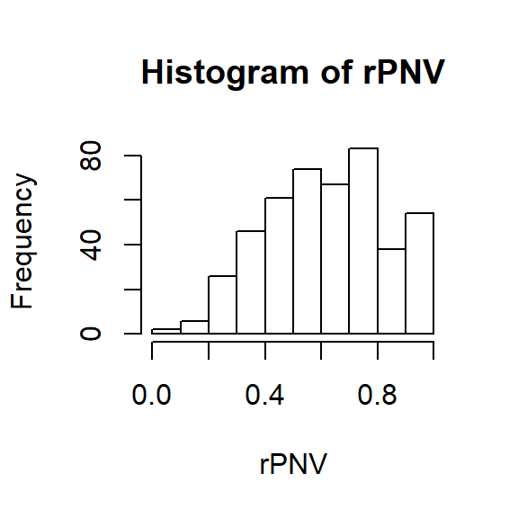

```r
#Inspeksjon av OE'enes frekvensfordeling langs rPNV'en
hist(rPNV)
```

#Importerer landskapsegenskapsprofiler fra regneark

### DENNE FUNKER IKKE ###lep <- read.table(“clipboard”,header=F)

### DENNE FUNKER IKKE ###attach(lep)

### DENNE FUNKER IKKE ###names(lep)

### DENNE FUNKER IKKE ###dim(lep)

#Beregner artsulikhet (PD)

### DENNE FUNKER IKKE ###dist <- vegdist(lep,method=“bray”)

### DENNE FUNKER IKKE ###dist

### DENNE FUNKER IKKE ####PD-verdiene er s? lave at det ikke er noe behov for ? bruke geodetisk avstand

### DENNE FUNKER IKKE ####Eksporterer til Excel

### DENNE FUNKER IKKE ###writeClipboard(as.character(dist)) #M? importeres som ‘character’ (jf. Crawley 2007: 77)

### DENNE FUNKER IKKE ####Importerer IA-estimater fra NiN2LAD5/OI-PD2

### DENNE FUNKER IKKE ###IAest.df <- read.table(“clipboard”,header=T)

### DENNE FUNKER IKKE ###attach(IAest.df)

### DENNE FUNKER IKKE ###names(IAest.df)

### DENNE FUNKER IKKE ###hist(IAest)

### DENNE FUNKER IKKE ###mean(IAest)

### DENNE FUNKER IKKE ###sd(IAest)

#### Finner prim?rn?kkelvariabler for identifiserte KLG ved RDA

#Skript for ? finne ortogonale prim?rn?kkelvariabler (rONV’er) i ei n?kkelvariabelgruppe

#Om n?dvendig: importerer relevante rPNV’er

#dta_pnv <- read-table(“clipboard”,header=T) #attach(dta_pnv)

#VE for 1 .akse i RDA’er gir VA(PNV)

```r
summary(oRDA_RE)$cont
```

[output not shown]

```r
oRDA_RE <- rda(av~RR1+Rug3_m+Tpi1h_a,scale=T) #er lik PNV, for den f?rst utvalgte gruppa
oRDA_SkP <- rda(av~Arbar_a + Sn_imp+Condition(RR1+Rug3_m+Tpi1h_a),scale=T)
oRDA_OI <- rda(av~IfIu+Gab_a+Condition(Arbar_a + Sn_imp+RR1+Rug3_m+Tpi1h_a),scale=T)

summary(oRDA_RE)$cont
```

```
## $importance
## Importance of components:
##                         RDA1    RDA2    RDA3     PC1     PC2     PC3
## Eigenvalue            8.7102 3.78332 1.34275 13.5097 6.30468 3.38955
## Proportion Explained  0.1037 0.04504 0.01599  0.1608 0.07506 0.04035
## Cumulative Proportion 0.1037 0.14873 0.16472  0.3255 0.40060 0.44096
##                           PC4     PC5     PC6     PC7     PC8     PC9
## Eigenvalue            2.94935 2.55090 2.38427 2.11766 1.79034 1.68600
## Proportion Explained  0.03511 0.03037 0.02838 0.02521 0.02131 0.02007
## Cumulative Proportion 0.47607 0.50643 0.53482 0.56003 0.58134 0.60141
##                          PC10    PC11    PC12    PC13    PC14    PC15
## Eigenvalue            1.59268 1.46033 1.39092 1.25873 1.17131 1.16590
## Proportion Explained  0.01896 0.01738 0.01656 0.01498 0.01394 0.01388
## Cumulative Proportion 0.62037 0.63776 0.65432 0.66930 0.68325 0.69713
##                          PC16    PC17    PC18    PC19   PC20    PC21
## Eigenvalue            1.14579 1.04939 0.98890 0.96320 0.9238 0.90266
## Proportion Explained  0.01364 0.01249 0.01177 0.01147 0.0110 0.01075
## Cumulative Proportion 0.71077 0.72326 0.73503 0.74650 0.7575 0.76824
##                          PC22     PC23     PC24    PC25     PC26     PC27
## Eigenvalue            0.84973 0.811874 0.792485 0.76103 0.745209 0.710525
## Proportion Explained  0.01012 0.009665 0.009434 0.00906 0.008872 0.008459
## Cumulative Proportion 0.77836 0.788024 0.797458 0.80652 0.815389 0.823848
##                           PC28     PC29     PC30    PC31     PC32     PC33
## Eigenvalue            0.665445 0.629870 0.617724 0.57705 0.561627 0.541607
## Proportion Explained  0.007922 0.007498 0.007354 0.00687 0.006686 0.006448
## Cumulative Proportion 0.831770 0.839268 0.846622 0.85349 0.860178 0.866626
##                          PC34     PC35     PC36     PC37     PC38     PC39
## Eigenvalue            0.52332 0.492371 0.483081 0.475508 0.460711 0.446778
## Proportion Explained  0.00623 0.005862 0.005751 0.005661 0.005485 0.005319
## Cumulative Proportion 0.87286 0.878717 0.884468 0.890129 0.895614 0.900932
##                           PC40     PC41     PC42     PC43    PC44     PC45
## Eigenvalue            0.433323 0.409604 0.382562 0.373022 0.35781 0.354361
## Proportion Explained  0.005159 0.004876 0.004554 0.004441 0.00426 0.004219
## Cumulative Proportion 0.906091 0.910967 0.915522 0.919962 0.92422 0.928441
##                           PC46     PC47     PC48     PC49     PC50
## Eigenvalue            0.331915 0.323960 0.315356 0.294458 0.280459
## Proportion Explained  0.003951 0.003857 0.003754 0.003505 0.003339
## Cumulative Proportion 0.932392 0.936249 0.940003 0.943508 0.946847
##                           PC51     PC52     PC53     PC54     PC55
## Eigenvalue            0.274269 0.260823 0.240439 0.232470 0.226153
## Proportion Explained  0.003265 0.003105 0.002862 0.002768 0.002692
## Cumulative Proportion 0.950112 0.953217 0.956080 0.958847 0.961539
##                           PC56     PC57     PC58     PC59     PC60
## Eigenvalue            0.219930 0.208229 0.197655 0.190421 0.187433
## Proportion Explained  0.002618 0.002479 0.002353 0.002267 0.002231
## Cumulative Proportion 0.964158 0.966636 0.968990 0.971256 0.973488
##                           PC61    PC62     PC63     PC64     PC65     PC66
## Eigenvalue            0.179375 0.16715 0.158444 0.151468 0.147476 0.143002
## Proportion Explained  0.002135 0.00199 0.001886 0.001803 0.001756 0.001702
## Cumulative Proportion 0.975623 0.97761 0.979499 0.981303 0.983058 0.984761
##                           PC67     PC68    PC69     PC70     PC71     PC72
## Eigenvalue            0.135980 0.129659 0.12266 0.117275 0.113045 0.108547
## Proportion Explained  0.001619 0.001544 0.00146 0.001396 0.001346 0.001292
## Cumulative Proportion 0.986379 0.987923 0.98938 0.990779 0.992125 0.993417
##                           PC73     PC74      PC75      PC76      PC77
## Eigenvalue            0.096128 0.086432 0.0780087 0.0684356 0.0653167
## Proportion Explained  0.001144 0.001029 0.0009287 0.0008147 0.0007776
## Cumulative Proportion 0.994562 0.995591 0.9965193 0.9973341 0.9981116
##                            PC78      PC79      PC80      PC81      PC82
## Eigenvalue            0.0548579 0.0422310 0.0281821 0.0201686 0.0131827
## Proportion Explained  0.0006531 0.0005028 0.0003355 0.0002401 0.0001569
## Cumulative Proportion 0.9987647 0.9992675 0.9996030 0.9998431 1.0000000
```

```r
summary(oRDA_SkP)$cont #gir aksenes egenverdier
```

```
## $importance
## Importance of components:
##                         RDA1    RDA2     PC1     PC2     PC3     PC4
## Eigenvalue            8.9390 1.20325 6.77667 5.47575 3.31767 2.83062
## Proportion Explained  0.1274 0.01715 0.09658 0.07804 0.04728 0.04034
## Cumulative Proportion 0.1274 0.14455 0.24113 0.31918 0.36646 0.40681
##                           PC5     PC6     PC7     PC8    PC9    PC10
## Eigenvalue            2.30444 2.12750 2.03828 1.68625 1.5856 1.46066
## Proportion Explained  0.03284 0.03032 0.02905 0.02403 0.0226 0.02082
## Cumulative Proportion 0.43965 0.46997 0.49902 0.52305 0.5457 0.56647
##                          PC11    PC12    PC13    PC14    PC15    PC16
## Eigenvalue            1.38082 1.34406 1.24494 1.16362 1.09643 1.04900
## Proportion Explained  0.01968 0.01916 0.01774 0.01658 0.01563 0.01495
## Cumulative Proportion 0.58615 0.60531 0.62305 0.63963 0.65526 0.67021
##                          PC17    PC18    PC19    PC20    PC21    PC22
## Eigenvalue            0.98531 0.96367 0.94300 0.88805 0.86713 0.82157
## Proportion Explained  0.01404 0.01373 0.01344 0.01266 0.01236 0.01171
## Cumulative Proportion 0.68426 0.69799 0.71143 0.72409 0.73645 0.74815
##                          PC23    PC24   PC25    PC26     PC27     PC28
## Eigenvalue            0.80593 0.76707 0.7440 0.71347 0.678565 0.651782
## Proportion Explained  0.01149 0.01093 0.0106 0.01017 0.009671 0.009289
## Cumulative Proportion 0.75964 0.77057 0.7812 0.79135 0.801017 0.810306
##                          PC29     PC30     PC31     PC32     PC33     PC34
## Eigenvalue            0.62304 0.582639 0.572250 0.537977 0.521086 0.500052
## Proportion Explained  0.00888 0.008304 0.008156 0.007667 0.007427 0.007127
## Cumulative Proportion 0.81919 0.827490 0.835646 0.843313 0.850740 0.857867
##                           PC35     PC36     PC37     PC38     PC39
## Eigenvalue            0.485194 0.476290 0.464695 0.441028 0.415464
## Proportion Explained  0.006915 0.006788 0.006623 0.006286 0.005921
## Cumulative Proportion 0.864782 0.871570 0.878194 0.884479 0.890401
##                           PC40     PC41     PC42     PC43     PC44
## Eigenvalue            0.395974 0.378398 0.367480 0.358710 0.344298
## Proportion Explained  0.005644 0.005393 0.005237 0.005112 0.004907
## Cumulative Proportion 0.896044 0.901437 0.906675 0.911787 0.916694
##                           PC45     PC46     PC47     PC48     PC49
## Eigenvalue            0.325728 0.321075 0.309777 0.298001 0.279212
## Proportion Explained  0.004642 0.004576 0.004415 0.004247 0.003979
## Cumulative Proportion 0.921337 0.925913 0.930328 0.934575 0.938554
##                           PC50     PC51     PC52     PC53     PC54
## Eigenvalue            0.274084 0.260089 0.240556 0.231931 0.226232
## Proportion Explained  0.003906 0.003707 0.003428 0.003306 0.003224
## Cumulative Proportion 0.942461 0.946168 0.949596 0.952902 0.956126
##                           PC55     PC56   PC57     PC58     PC59     PC60
## Eigenvalue            0.218445 0.210618 0.1964 0.188690 0.186355 0.168145
## Proportion Explained  0.003113 0.003002 0.0028 0.002689 0.002656 0.002396
## Cumulative Proportion 0.959239 0.962241 0.9650 0.967730 0.970386 0.972783
##                           PC61     PC62     PC63     PC64    PC65     PC66
## Eigenvalue            0.167084 0.152082 0.149199 0.145159 0.14172 0.131674
## Proportion Explained  0.002381 0.002168 0.002126 0.002069 0.00202 0.001877
## Cumulative Proportion 0.975164 0.977332 0.979458 0.981527 0.98355 0.985423
##                           PC67     PC68     PC69     PC70     PC71
## Eigenvalue            0.125841 0.117415 0.113357 0.108551 0.096571
## Proportion Explained  0.001794 0.001673 0.001616 0.001547 0.001376
## Cumulative Proportion 0.987217 0.988890 0.990506 0.992053 0.993429
##                           PC72     PC73      PC74      PC75      PC76
## Eigenvalue            0.089639 0.078544 0.0685229 0.0655213 0.0549459
## Proportion Explained  0.001278 0.001119 0.0009766 0.0009338 0.0007831
## Cumulative Proportion 0.994707 0.995826 0.9968030 0.9977368 0.9985199
##                            PC77      PC78      PC79     PC80
## Eigenvalue            0.0422652 0.0282169 0.0201742 0.013190
## Proportion Explained  0.0006024 0.0004022 0.0002875 0.000188
## Cumulative Proportion 0.9991223 0.9995245 0.9998120 1.000000
```

```r
summary(oRDA_OI)$cont
```

```
## $importance
## Importance of components:
##                          RDA1    RDA2     PC1     PC2     PC3     PC4
## Eigenvalue            4.31384 1.85098 5.73975 3.48573 2.61238 2.30324
## Proportion Explained  0.07187 0.03084 0.09563 0.05807 0.04352 0.03837
## Cumulative Proportion 0.07187 0.10271 0.19834 0.25641 0.29994 0.33831
##                           PC5    PC6     PC7     PC8     PC9    PC10
## Eigenvalue            2.04870 1.9985 1.77524 1.60334 1.57608 1.45048
## Proportion Explained  0.03413 0.0333 0.02958 0.02671 0.02626 0.02417
## Cumulative Proportion 0.37244 0.4057 0.43532 0.46203 0.48829 0.51245
##                          PC11    PC12    PC13    PC14    PC15    PC16
## Eigenvalue            1.34323 1.25311 1.17877 1.10503 1.02925 0.98964
## Proportion Explained  0.02238 0.02088 0.01964 0.01841 0.01715 0.01649
## Cumulative Proportion 0.53483 0.55571 0.57535 0.59376 0.61091 0.62740
##                         PC17    PC18    PC19    PC20    PC21    PC22
## Eigenvalue            0.9661 0.93971 0.89610 0.85929 0.83914 0.78660
## Proportion Explained  0.0161 0.01566 0.01493 0.01432 0.01398 0.01311
## Cumulative Proportion 0.6435 0.65915 0.67408 0.68839 0.70237 0.71548
##                         PC23    PC24    PC25   PC26    PC27    PC28
## Eigenvalue            0.7621 0.74834 0.70739 0.7023 0.66711 0.61979
## Proportion Explained  0.0127 0.01247 0.01179 0.0117 0.01111 0.01033
## Cumulative Proportion 0.7282 0.74065 0.75243 0.7641 0.77525 0.78557
##                           PC29     PC30     PC31     PC32     PC33
## Eigenvalue            0.586142 0.564683 0.545155 0.537542 0.503326
## Proportion Explained  0.009766 0.009408 0.009083 0.008956 0.008386
## Cumulative Proportion 0.795339 0.804747 0.813829 0.822785 0.831171
##                           PC34     PC35     PC36     PC37     PC38
## Eigenvalue            0.498135 0.479134 0.462126 0.451631 0.416848
## Proportion Explained  0.008299 0.007983 0.007699 0.007524 0.006945
## Cumulative Proportion 0.839470 0.847453 0.855152 0.862677 0.869622
##                           PC39     PC40     PC41     PC42     PC43
## Eigenvalue            0.399445 0.382096 0.376505 0.365382 0.343990
## Proportion Explained  0.006655 0.006366 0.006273 0.006088 0.005731
## Cumulative Proportion 0.876277 0.882643 0.888916 0.895003 0.900734
##                           PC44    PC45     PC46     PC47     PC48     PC49
## Eigenvalue            0.329591 0.32169 0.310089 0.303066 0.285195 0.273762
## Proportion Explained  0.005491 0.00536 0.005166 0.005049 0.004752 0.004561
## Cumulative Proportion 0.906226 0.91159 0.916752 0.921801 0.926552 0.931113
##                           PC50     PC51     PC52     PC53     PC54
## Eigenvalue            0.269112 0.250927 0.235079 0.229638 0.218197
## Proportion Explained  0.004484 0.004181 0.003917 0.003826 0.003635
## Cumulative Proportion 0.935597 0.939778 0.943694 0.947520 0.951156
##                           PC55     PC56     PC57     PC58     PC59
## Eigenvalue            0.211077 0.206916 0.190224 0.185393 0.171731
## Proportion Explained  0.003517 0.003447 0.003169 0.003089 0.002861
## Cumulative Proportion 0.954672 0.958120 0.961289 0.964378 0.967239
##                           PC60     PC61     PC62    PC63    PC64     PC65
## Eigenvalue            0.162924 0.160546 0.152069 0.14706 0.14283 0.135966
## Proportion Explained  0.002714 0.002675 0.002534 0.00245 0.00238 0.002265
## Cumulative Proportion 0.969953 0.972628 0.975162 0.97761 0.97999 0.982257
##                           PC66     PC67     PC68     PC69     PC70
## Eigenvalue            0.125364 0.124610 0.115983 0.112789 0.108457
## Proportion Explained  0.002089 0.002076 0.001932 0.001879 0.001807
## Cumulative Proportion 0.984345 0.986421 0.988354 0.990233 0.992040
##                           PC71     PC72     PC73     PC74      PC75
## Eigenvalue            0.095962 0.087299 0.071016 0.064382 0.0550785
## Proportion Explained  0.001599 0.001454 0.001183 0.001073 0.0009176
## Cumulative Proportion 0.993639 0.995093 0.996276 0.997349 0.9982666
##                            PC76      PC77      PC78      PC79
## Eigenvalue            0.0423860 0.0282867 0.0202033 0.0131623
## Proportion Explained  0.0007062 0.0004713 0.0003366 0.0002193
## Cumulative Proportion 0.9989728 0.9994441 0.9997807 1.0000000
```

```r
#Ekstraksjon av ONV; dette er vektorer
ONV_RE <- scores(oRDA_RE, display="lc", choices=1, scaling=1)
ONV_SkP <- -scores(oRDA_SkP, display="lc", choices=1, scaling=1)
ONV_OI <- -scores(oRDA_OI, display="lc", choices=1, scaling=1)
```

```r
#Sjekker om rONV'en har samme fortegn som variablen(e) som karakteriserer den, og gjlrb om n?dvendig ny ekstraksjon av sk?rer med motsatt fortegn
cor.test(ONV_RE,Rr1_m,method="k")
```

```
##
##  Kendall's rank correlation tau
##
## data:  ONV_RE and Rr1_m
## z = -24.492, p-value < 2.2e-16
## alternative hypothesis: true tau is not equal to 0
## sample estimates:
##        tau
## -0.7690107
```

```r
cor.test(ONV_SkP,Arbar_a,method="k")
```

```
##
##  Kendall's rank correlation tau
##
## data:  ONV_SkP and Arbar_a
## z = -23.904, p-value < 2.2e-16
## alternative hypothesis: true tau is not equal to 0
## sample estimates:
##        tau
## -0.7881209
```

```r
cor.test(ONV_OI,IfIu,method="k")
```

```
##
##  Kendall's rank correlation tau
##
## data:  ONV_OI and IfIu
## z = 14.704, p-value < 2.2e-16
## alternative hypothesis: true tau is not equal to 0
## sample estimates:
##       tau
## 0.4650136
```

#Eksporterer evt sk?rer langs ONV’ene til Excel writeClipboard(as.character(ONV_RE)) writeClipboard(as.character(ONV_SkP)) writeClipboard(as.character(ONV_OI))

```r
#Rangerer ONV'ene

rONV_RE <- (ONV_RE-min(ONV_RE))/(max(ONV_RE)-min(ONV_RE)) #Tar vare p? de korrigerte prim?rn?kkelvariablene
rONV_SkP <- (ONV_SkP-min(ONV_SkP))/(max(ONV_SkP)-min(ONV_SkP))
rONV_OI <- (ONV_OI-min(ONV_OI))/(max(ONV_OI)-min(ONV_OI))
```

#Eksporterer rONV-sk?rer til Excel

writeClipboard(as.character(rONV_RE)) writeClipboard(as.character(rONV_SkP)) writeClipboard(as.character(rONV_OI))

#### Beregning av LA mellom KLG-klasser ved bruk av PD

#Importerer om n?dvendig rPNVer fra Excel:

#rPNV <- read.table(“clipboard”,header=T) #attach(rPNV) #names(rPNV)

#Analyse av KLG’er representert ved rangerte n?kkelvariabler

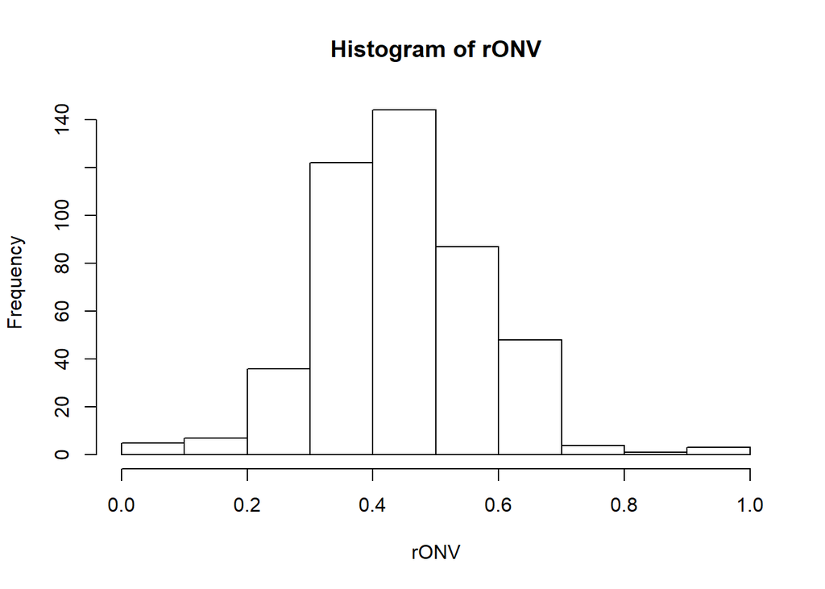

```r
rONV <- rONV_OI

#Inspeksjon av OE'enes frekvensfordeling langs rPNV'en
hist(rONV)
```

#Importerer landskapsegenskapsprofiler fra regneark ### DENNE FUNKER IKKE ### ### DENNE FUNKER IKKE ### lep <- read.table(“clipboard”,header=F) ### DENNE FUNKER IKKE ###lep <- as.numeric(lep) ### DENNE FUNKER IKKE ###attach(lep) ### DENNE FUNKER IKKE ###names(lep)

### DENNE FUNKER IKKE ###dim(lep)

### DENNE FUNKER IKKE ####Beregner artsulikhet (PD)

### DENNE FUNKER IKKE ###dist <- vegdist(lep,method=“bray”)

### DENNE FUNKER IKKE ###dist

### DENNE FUNKER IKKE ####PD-verdiene er s? lave at det ikke er noe behov for ? bruke geodetisk avstand

### DENNE FUNKER IKKE ####Eksporterer til Excel

### DENNE FUNKER IKKE ###writeClipboard(as.character(dist)) #M? importeres som ‘character’ (jf. Crawley 2007: 77)

### DENNE FUNKER IKKE ###cor.test(IfIu,rONV_AP)

### DENNE FUNKER IKKE ### SLUTT

#### Analyser av samvariasjon mellom reskalerte rONV’er (sONV)

#Fig. 1. 1 IyK mot 2 RE; SN som symboler og isolinjer for Oyst_i

```r
#sONV'er som skal plottes mot hverandre
s1 <- sONV_IyK
s2 <- sONV_RE
```

#Finner koordinatene for hj?rner i det ‘plotteomr?det’ med koordinater (x1, x2, y1, y2) som gir #like enheter p? begge akser. Vi holder x1, x2 og y1 faste og bestemmer y2 slik at (x2-x1)/(y2-y1) i plt=c(x1,x2,y1,y2) #blir lik max(s1)/max(s2) #Det krever at y2 = [(x2-x1)*max(s2) + y1*max(s1)]/max(s1) #Setter vi x1, x2 og y1 konstante, f?r vi:

```r
y2 <- (0.8*max(s2)+0.15*max(s1))/max(s1)
y2
```

```
## [1] 0.7467213
```

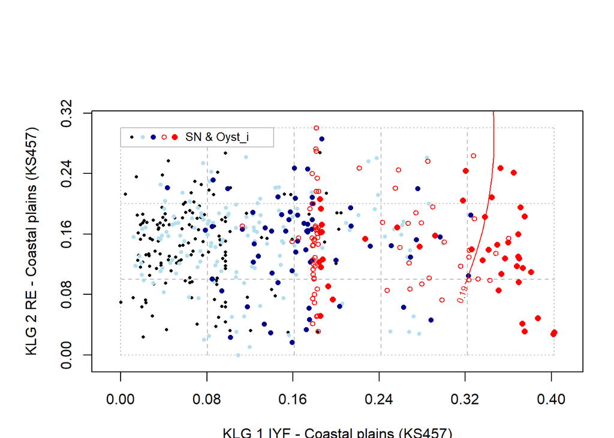

```r
#Plotter SN-klasser p? figuren, og legger p? isolinjer for Oyst_i
par(plt=c(0.15, 0.95, 0.15, y2))
plot(s1,s2,xlab="KLG 1 IYF - Coastal plains (KS457)",ylab="KLG 2 RE - Coastal plains (KS457)",xlim=c(-0.01,max(s1)+0.01),ylim=c(-0.01,max(s2)+0.01),xaxp=c(0,0.4,5),yaxp=c(0,0.4,5),type="n") #Grunnlag for plotting av symboler etc.
lines(c(0,max(s1)),c(max(s2),max(s2)),lty=3,col=8)
lines(c(0,max(s1)),c(0,0),lty=3,col=8)
lines(c(0,0),c(0,max(s2)),lty=3,col=8)
lines(c(max(s1),max(s1)),c(0,max(s2)),lty=3,col=8)

lines(c(0,max(s1)),c(max(s2)/3,max(s2)/3),lty=2,col=8)
lines(c(0,max(s1)),c(2*max(s2)/3,2*max(s2)/3),lty=3,col=8)
lines(c(0.2*max(s1),0.2*max(s1)),c(0,max(s2)-0.025),lty=2,col=8)
lines(c(0.4*max(s1),0.4*max(s1)),c(0,max(s2)),lty=2,col=8)
lines(c(0.6*max(s1),0.6*max(s1)),c(0,max(s2)),lty=2,col=8)
lines(c(0.8*max(s1),0.8*max(s1)),c(0,max(s2)),lty=2,col=8)

lines(c(0,0.142),c(max(s2),max(s2)),col=8)
lines(c(0,0.142),c(max(s2)-0.025,max(s2)-0.025),col=8)
lines(c(0.142,0.142),c(max(s2)-0.025,max(s2)),col=8)
lines(c(0,0),c(max(s2)-0.025,max(s2)),col=8)
points(0.01,max(s2)-0.012,pch=16,cex=0.5,col="black")
points(0.02,max(s2)-0.012,pch=16,cex=0.6,col="lightblue2")
points(0.03,max(s2)-0.012,pch=16,cex=0.75,col="darkblue")
points(0.04,max(s2)-0.012,pch=1,cex=0.75,col="red")
points(0.05,max(s2)-0.012,pch=16,cex=0.9,col="red")

text(0.06,max(s2)-0.012,"SN & Oyst_i",adj=0,cex=0.8)
points(s1[SN==1],s2[SN==1],pch=16,cex=0.5,col=1)
points(s1[SN==2],s2[SN==2],pch=16,cex=0.6,col="lightblue2")
points(s1[SN==3],s2[SN==3],pch=16,cex=0.75,col="darkblue")
points(s1[SN==4],s2[SN==4],pch=1,cex=0.75,col="red")
points(s1[SN==5],s2[SN==5],pch=16,cex=0.9,col="red")

os <- ordisurf(snv[,c(1,2)],Oyst_i,display="sites",levels=c(0.19,0.454,0.574,0.643,0.693,0.733,0.768,0.798), col="red",add=T) #inkluderer plotting p? eksisterende ordinasjonsdiagram
```

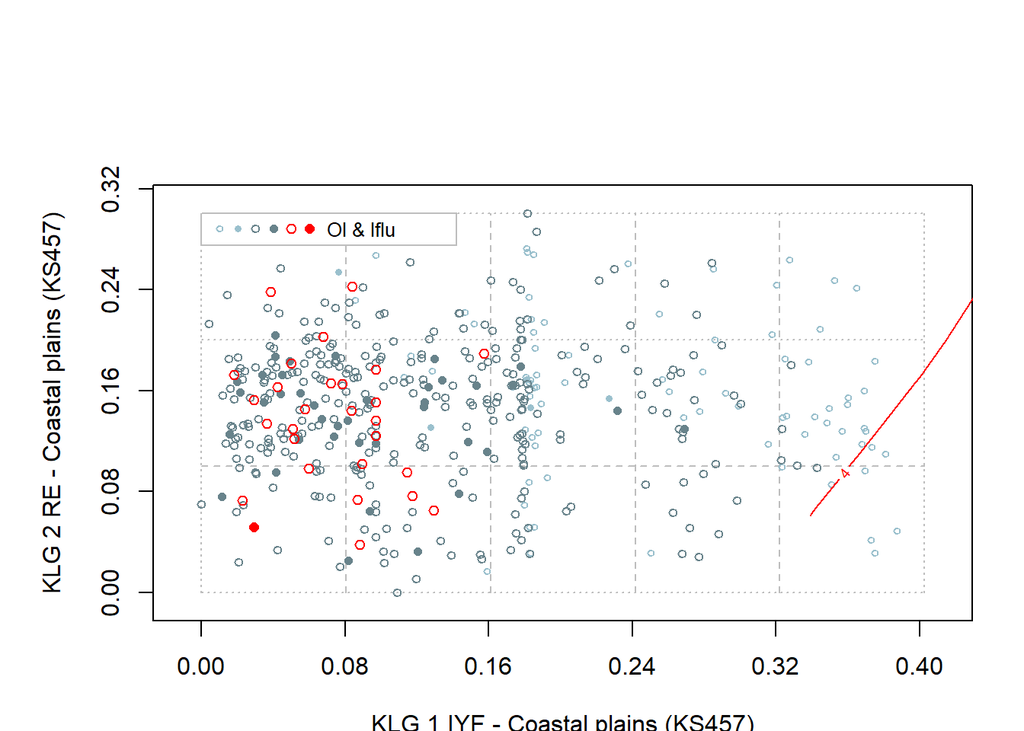

```r
  #Plotter OI-klasser p? figuren, og legger p? isolinjer for IfIu
  par(plt=c(0.15, 0.95, 0.15, y2))
plot(s1,s2,xlab="KLG 1 IYF - Coastal plains (KS457)",ylab="KLG 2 RE - Coastal plains (KS457)",xlim=c(-0.01,max(s1)+0.01),ylim=c(-0.01,max(s2)+0.01),xaxp=c(0,0.4,5),yaxp=c(0,0.4,5),type="n") #Grunnlag for plotting av symboler etc.
lines(c(0,max(s1)),c(max(s2),max(s2)),lty=3,col=8)
lines(c(0,max(s1)),c(0,0),lty=3,col=8)
lines(c(0,0),c(0,max(s2)),lty=3,col=8)
lines(c(max(s1),max(s1)),c(0,max(s2)),lty=3,col=8)

lines(c(0,max(s1)),c(max(s2)/3,max(s2)/3),lty=2,col=8)
lines(c(0,max(s1)),c(2*max(s2)/3,2*max(s2)/3),lty=3,col=8)
lines(c(0.2*max(s1),0.2*max(s1)),c(0,max(s2)-0.025),lty=2,col=8)
lines(c(0.4*max(s1),0.4*max(s1)),c(0,max(s2)),lty=2,col=8)
lines(c(0.6*max(s1),0.6*max(s1)),c(0,max(s2)),lty=2,col=8)
lines(c(0.8*max(s1),0.8*max(s1)),c(0,max(s2)),lty=2,col=8)

lines(c(0,0.142),c(max(s2),max(s2)),col=8)
lines(c(0,0.142),c(max(s2)-0.025,max(s2)-0.025),col=8)
lines(c(0.142,0.142),c(max(s2)-0.025,max(s2)),col=8)
lines(c(0,0),c(max(s2)-0.025,max(s2)),col=8)
points(0.01,max(s2)-0.012,pch=1,cex=0.6,col="lightblue3")
points(0.02,max(s2)-0.012,pch=16,cex=0.6,col="lightblue3")
points(0.03,max(s2)-0.012,pch=1,cex=0.75,col="lightblue4")
points(0.04,max(s2)-0.012,pch=16,cex=0.75,col="lightblue4")
points(0.05,max(s2)-0.012,pch=1,cex=0.9,col="red")
points(0.06,max(s2)-0.012,pch=16,cex=0.9,col="red")

text(0.07,max(s2)-0.012,"OI & IfIu",adj=0,cex=0.8)
points(s1[OI==1],s2[OI==1],pch=1,cex=0.6,col="lightblue3")
points(s1[OI==2],s2[OI==2],pch=16,cex=0.6,col="lightblue3")
points(s1[OI==3],s2[OI==3],pch=1,cex=0.75,col="lightblue4")
points(s1[OI==4],s2[OI==4],pch=16,cex=0.75,col="lightblue4")
points(s1[OI==5],s2[OI==5],pch=1,cex=0.9,col="red")
points(s1[OI==6],s2[OI==6],pch=16,cex=0.9,col="red")

os <- ordisurf(snv[,c(1,2)],IfIu,display="sites",levels=c(1,2,4,6,8,10,11), col="red",add=T) #inkluderer plotting p? eksisterende ordinasjonsdiagram
```

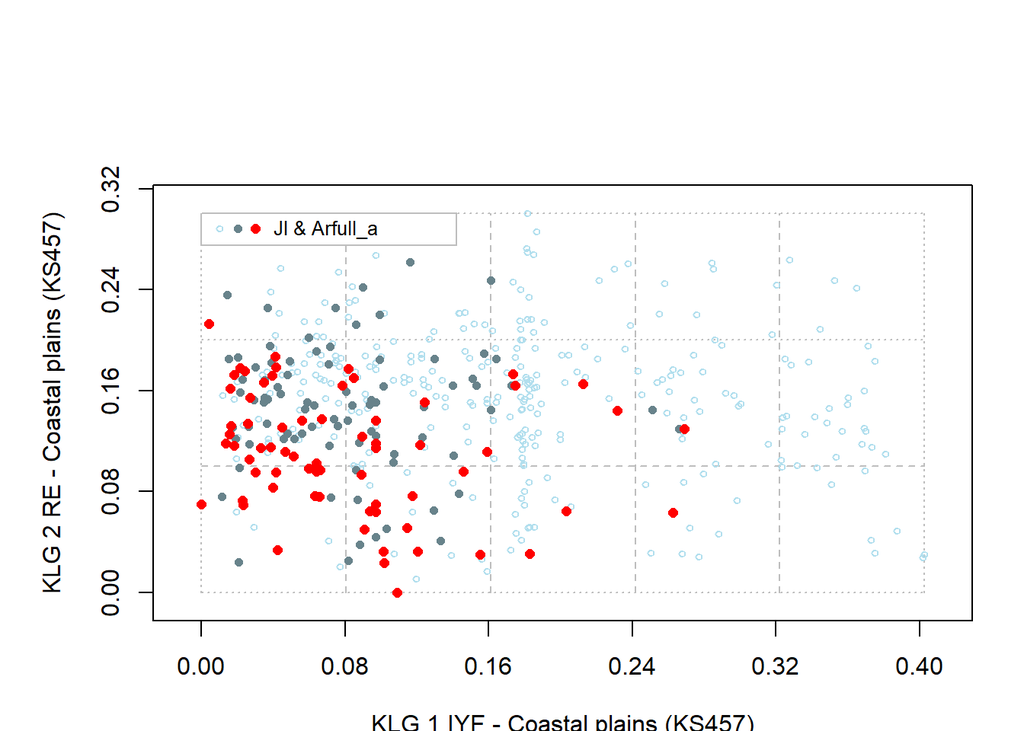

```r
#Plotter JP-klasser p? figuren, og legger p? isolinjer for Ar_full
  par(plt=c(0.15, 0.95, 0.15, y2))
plot(s1,s2,xlab="KLG 1 IYF - Coastal plains (KS457)",ylab="KLG 2 RE - Coastal plains (KS457)",xlim=c(-0.01,max(s1)+0.01),ylim=c(-0.01,max(s2)+0.01),xaxp=c(0,0.4,5),yaxp=c(0,0.4,5),type="n") #Grunnlag for plotting av symboler etc.
lines(c(0,max(s1)),c(max(s2),max(s2)),lty=3,col=8)
lines(c(0,max(s1)),c(0,0),lty=3,col=8)
lines(c(0,0),c(0,max(s2)),lty=3,col=8)
lines(c(max(s1),max(s1)),c(0,max(s2)),lty=3,col=8)

lines(c(0,max(s1)),c(max(s2)/3,max(s2)/3),lty=2,col=8)
lines(c(0,max(s1)),c(2*max(s2)/3,2*max(s2)/3),lty=3,col=8)
lines(c(0.2*max(s1),0.2*max(s1)),c(0,max(s2)-0.025),lty=2,col=8)
lines(c(0.4*max(s1),0.4*max(s1)),c(0,max(s2)),lty=2,col=8)
lines(c(0.6*max(s1),0.6*max(s1)),c(0,max(s2)),lty=2,col=8)
lines(c(0.8*max(s1),0.8*max(s1)),c(0,max(s2)),lty=2,col=8)

lines(c(0,0.142),c(max(s2),max(s2)),col=8)
lines(c(0,0.142),c(max(s2)-0.025,max(s2)-0.025),col=8)
lines(c(0.142,0.142),c(max(s2)-0.025,max(s2)),col=8)
lines(c(0,0),c(max(s2)-0.025,max(s2)),col=8)
points(0.01,max(s2)-0.012,pch=1,cex=0.6,col="lightblue2")
points(0.02,max(s2)-0.012,pch=16,cex=0.75,col="lightblue4")
points(0.03,max(s2)-0.012,pch=16,cex=0.9,col="red")

text(0.04,max(s2)-0.012,"JI & Arfull_a",adj=0,cex=0.8)

points(s1[JP==1],s2[JP==1],pch=1,cex=0.6,col="lightblue2")
points(s1[JP==2],s2[JP==2],pch=16,cex=0.75,col="lightblue4")
points(s1[JP==3],s2[JP==3],pch=16,cex=0.9,col="red")

os <- ordisurf(snv[,c(1,2)],Arfull_a,display="sites",levels=c(0.1,0.4,0.6), col="red",add=T) #inkluderer plotting p? eksisterende ordinasjonsdiagram
```

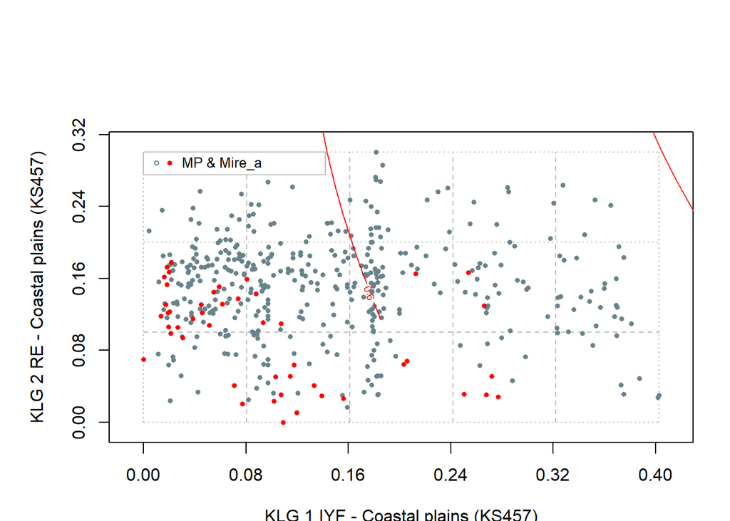

```r
#Plotter MI-klasser p? figuren, og legger p? isolinjer for Mire_a
  par(plt=c(0.15, 0.95, 0.15, y2))
plot(s1,s2,xlab="KLG 1 IYF - Coastal plains (KS457)",ylab="KLG 2 RE - Coastal plains (KS457)",xlim=c(-0.01,max(s1)+0.01),ylim=c(-0.01,max(s2)+0.01),xaxp=c(0,0.4,5),yaxp=c(0,0.4,5),type="n") #Grunnlag for plotting av symboler etc.
lines(c(0,max(s1)),c(max(s2),max(s2)),lty=3,col=8)
lines(c(0,max(s1)),c(0,0),lty=3,col=8)
lines(c(0,0),c(0,max(s2)),lty=3,col=8)
lines(c(max(s1),max(s1)),c(0,max(s2)),lty=3,col=8)

lines(c(0,max(s1)),c(max(s2)/3,max(s2)/3),lty=2,col=8)
lines(c(0,max(s1)),c(2*max(s2)/3,2*max(s2)/3),lty=3,col=8)
lines(c(0.2*max(s1),0.2*max(s1)),c(0,max(s2)-0.025),lty=2,col=8)
lines(c(0.4*max(s1),0.4*max(s1)),c(0,max(s2)),lty=2,col=8)
lines(c(0.6*max(s1),0.6*max(s1)),c(0,max(s2)),lty=2,col=8)
lines(c(0.8*max(s1),0.8*max(s1)),c(0,max(s2)),lty=2,col=8)

lines(c(0,0.142),c(max(s2),max(s2)),col=8)
lines(c(0,0.142),c(max(s2)-0.025,max(s2)-0.025),col=8)
lines(c(0.142,0.142),c(max(s2)-0.025,max(s2)),col=8)
lines(c(0,0),c(max(s2)-0.025,max(s2)),col=8)
points(0.01,max(s2)-0.012,pch=1,cex=0.6,col="lightblue4")
points(0.02,max(s2)-0.012,pch=16,cex=0.6,col="red")

text(0.03,max(s2)-0.012,"MP & Mire_a",adj=0,cex=0.8)

points(s1[MP==1],s2[MP==1],pch=16,cex=0.6,col="lightblue4")
points(s1[MP==2],s2[MP==2],pch=16,cex=0.6,col="red")

os <- ordisurf(snv[,c(1,2)],Mire_a,display="sites",levels=c(0.05,0.1,0.2,0.4,0.6,0.8), col="red",add=T) #inkluderer plotting p? eksisterende ordinasjonsdiagram
```

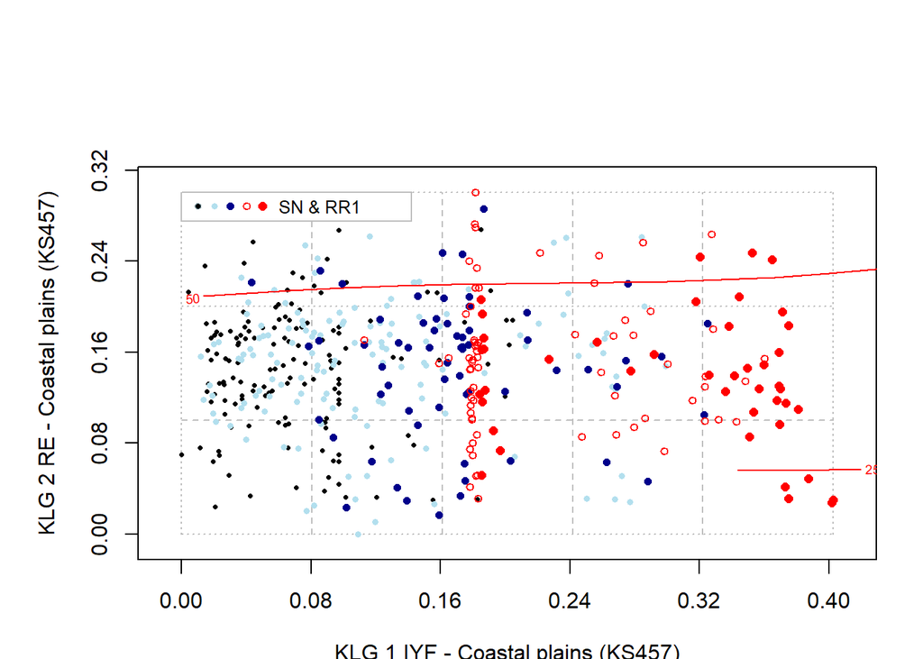

```r
#Plotter RE-klasser p? figuren, og legger p? isolinjer for RR1
par(plt=c(0.15, 0.95, 0.15, y2))
plot(s1,s2,xlab="KLG 1 IYF - Coastal plains (KS457)",ylab="KLG 2 RE - Coastal plains (KS457)",xlim=c(-0.01,max(s1)+0.01),ylim=c(-0.01,max(s2)+0.01),xaxp=c(0,0.4,5),yaxp=c(0,0.4,5),type="n") #Grunnlag for plotting av symboler etc.
lines(c(0,max(s1)),c(max(s2),max(s2)),lty=3,col=8)
lines(c(0,max(s1)),c(0,0),lty=3,col=8)
lines(c(0,0),c(0,max(s2)),lty=3,col=8)
lines(c(max(s1),max(s1)),c(0,max(s2)),lty=3,col=8)

lines(c(0,max(s1)),c(max(s2)/3,max(s2)/3),lty=2,col=8)
lines(c(0,max(s1)),c(2*max(s2)/3,2*max(s2)/3),lty=3,col=8)
lines(c(0.2*max(s1),0.2*max(s1)),c(0,max(s2)-0.025),lty=2,col=8)
lines(c(0.4*max(s1),0.4*max(s1)),c(0,max(s2)),lty=2,col=8)
lines(c(0.6*max(s1),0.6*max(s1)),c(0,max(s2)),lty=2,col=8)
lines(c(0.8*max(s1),0.8*max(s1)),c(0,max(s2)),lty=2,col=8)

lines(c(0,0.142),c(max(s2),max(s2)),col=8)
lines(c(0,0.142),c(max(s2)-0.025,max(s2)-0.025),col=8)
lines(c(0.142,0.142),c(max(s2)-0.025,max(s2)),col=8)
lines(c(0,0),c(max(s2)-0.025,max(s2)),col=8)
points(0.01,max(s2)-0.012,pch=1,cex=0.6,col="lightblue4")
points(0.02,max(s2)-0.012,pch=16,cex=0.6,col="red")

points(0.01,max(s2)-0.012,pch=16,cex=0.5,col="black")
points(0.02,max(s2)-0.012,pch=16,cex=0.6,col="lightblue2")
points(0.03,max(s2)-0.012,pch=16,cex=0.75,col="darkblue")
points(0.04,max(s2)-0.012,pch=1,cex=0.75,col="red")
points(0.05,max(s2)-0.012,pch=16,cex=0.9,col="red")

text(0.06,max(s2)-0.012,"SN & RR1",adj=0,cex=0.8)
points(s1[SN==1],s2[SN==1],pch=16,cex=0.5,col=1)
points(s1[SN==2],s2[SN==2],pch=16,cex=0.6,col="lightblue2")
points(s1[SN==3],s2[SN==3],pch=16,cex=0.75,col="darkblue")
points(s1[SN==4],s2[SN==4],pch=1,cex=0.75,col="red")
points(s1[SN==5],s2[SN==5],pch=16,cex=0.9,col="red")

os <- ordisurf(snv[,c(1,2)],RR1,display="sites",levels=c(25,50,75,100,150,200), col="red",add=T) #inkluderer plotting p? eksisterende ordinasjonsdiagram
```

```r
###
```

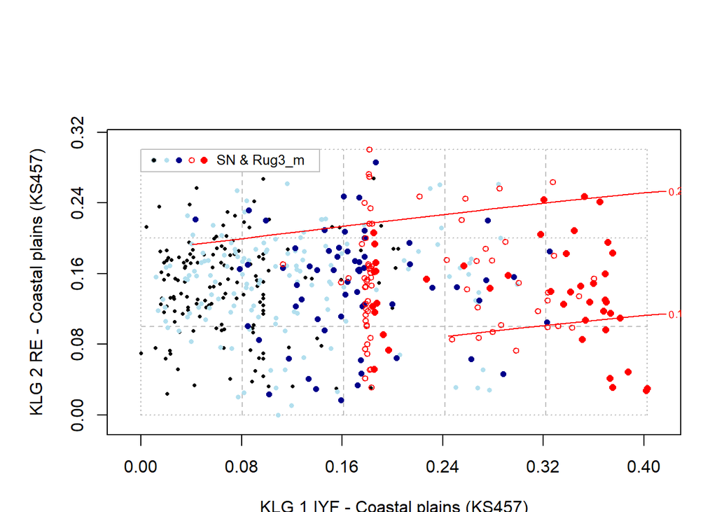

```r
#Plotter RE-klasser p? figuren, og legger p? isolinjer for Rug3_m
par(plt=c(0.15, 0.95, 0.15, y2))
plot(s1,s2,xlab="KLG 1 IYF - Coastal plains (KS457)",ylab="KLG 2 RE - Coastal plains (KS457)",xlim=c(-0.01,max(s1)+0.01),ylim=c(-0.01,max(s2)+0.01),xaxp=c(0,0.4,5),yaxp=c(0,0.4,5),type="n") #Grunnlag for plotting av symboler etc.
lines(c(0,max(s1)),c(max(s2),max(s2)),lty=3,col=8)
lines(c(0,max(s1)),c(0,0),lty=3,col=8)
lines(c(0,0),c(0,max(s2)),lty=3,col=8)
lines(c(max(s1),max(s1)),c(0,max(s2)),lty=3,col=8)

lines(c(0,max(s1)),c(max(s2)/3,max(s2)/3),lty=2,col=8)
lines(c(0,max(s1)),c(2*max(s2)/3,2*max(s2)/3),lty=3,col=8)
lines(c(0.2*max(s1),0.2*max(s1)),c(0,max(s2)-0.025),lty=2,col=8)
lines(c(0.4*max(s1),0.4*max(s1)),c(0,max(s2)),lty=2,col=8)
lines(c(0.6*max(s1),0.6*max(s1)),c(0,max(s2)),lty=2,col=8)
lines(c(0.8*max(s1),0.8*max(s1)),c(0,max(s2)),lty=2,col=8)

lines(c(0,0.142),c(max(s2),max(s2)),col=8)
lines(c(0,0.142),c(max(s2)-0.025,max(s2)-0.025),col=8)
lines(c(0.142,0.142),c(max(s2)-0.025,max(s2)),col=8)
lines(c(0,0),c(max(s2)-0.025,max(s2)),col=8)
points(0.01,max(s2)-0.012,pch=1,cex=0.6,col="lightblue4")
points(0.02,max(s2)-0.012,pch=16,cex=0.6,col="red")

points(0.01,max(s2)-0.012,pch=16,cex=0.5,col="black")
points(0.02,max(s2)-0.012,pch=16,cex=0.6,col="lightblue2")
points(0.03,max(s2)-0.012,pch=16,cex=0.75,col="darkblue")
points(0.04,max(s2)-0.012,pch=1,cex=0.75,col="red")
points(0.05,max(s2)-0.012,pch=16,cex=0.9,col="red")

text(0.06,max(s2)-0.012,"SN & Rug3_m",adj=0,cex=0.8)
points(s1[SN==1],s2[SN==1],pch=16,cex=0.5,col=1)
points(s1[SN==2],s2[SN==2],pch=16,cex=0.6,col="lightblue2")
points(s1[SN==3],s2[SN==3],pch=16,cex=0.75,col="darkblue")
points(s1[SN==4],s2[SN==4],pch=1,cex=0.75,col="red")
points(s1[SN==5],s2[SN==5],pch=16,cex=0.9,col="red")

os <- ordisurf(snv[,c(1,2)],Rug3_m,display="sites",levels=c(0.1,0.2,0.4,0.6,0.8,0.9), col="red",add=T) #inkluderer plotting p? eksisterende ordinasjonsdiagram
```

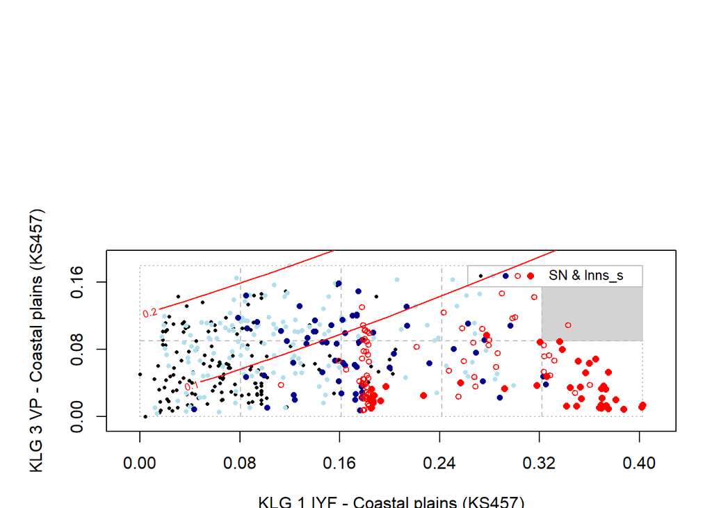

```r
#Fig. 2. 1 IyK mot 3 VP; SN som symboler og isolinjer for Inns_s

#sONV'er som skal plottes mot hverandre
s1 <- sONV_IyK
s2 <- sONV_VP

#Finner koordinatene for hj?rner i det 'plotteomr?det' med koordinater (x1, x2, y1, y2) som gir
#like enheter p? begge akser. Vi holder x1, x2 og y1 faste og bestemmer y2 slik at (x2-x1)/(y2-y1) i plt=c(x1,x2,y1,y2)
#blir lik max(s1)/max(s2)
#Det krever at y2 = [(x2-x1)*max(s2) + y1*max(s1)]/max(s1)
#Setter vi x1, x2 og y1 konstante, f?r vi:
y2 <- (0.8*max(s2)+0.15*max(s1))/max(s1)
#y2

par(plt=c(0.15, 0.95, 0.15, y2))
plot(s1,s2,xlab="KLG 1 IYF - Coastal plains (KS457)",ylab="KLG 3 VP - Coastal plains (KS457)",xlim=c(-0.01,max(s1)+0.01),ylim=c(-0.01,max(s2)+0.01),xaxp=c(0,0.4,5),yaxp=c(0,0.4,5),type="n") #Grunnlag for plotting av symboler etc.
lines(c(0,max(s1)),c(max(s2),max(s2)),lty=3,col=8)
lines(c(0,max(s1)),c(0,0),lty=3,col=8)
lines(c(0,0),c(0,max(s2)),lty=3,col=8)
lines(c(max(s1),max(s1)),c(0,max(s2)),lty=3,col=8)

polygon(c(4*max(s1)/5,4*max(s1)/5,max(s1),max(s1)),c(max(s2)/2,max(s2)-0.025,max(s2)-0.025,max(s2)/2),col="lightgray")
polygon(c(4*max(s1)/5,4*max(s1)/5,max(s1),max(s1)),c(max(s2)/2,max(s2)-0.025,max(s2)-0.025,max(s2)/2),col="lightgray",density=10) #legger egentlig et skr?tt raster opp?, og fjerner streken rundt

lines(c(0,max(s1)),c(max(s2)/2,max(s2)/2),lty=2,col=8)
lines(c(0.2*max(s1),0.2*max(s1)),c(0,max(s2)),lty=2,col=8)
lines(c(0.4*max(s1),0.4*max(s1)),c(0,max(s2)),lty=2,col=8)
lines(c(0.6*max(s1),0.6*max(s1)),c(0,max(s2)),lty=2,col=8)
lines(c(0.8*max(s1),0.8*max(s1)),c(0,max(s2)-0.025),lty=2,col=8)

lines(c(max(s1)-0.14,max(s1)),c(max(s2),max(s2)),col=8)
lines(c(max(s1)-0.14,max(s1)),c(max(s2)-0.025,max(s2)-0.025),col=8)
lines(c(max(s1)-0.14,max(s1)-0.14),c(max(s2)-0.025,max(s2)),col=8)
lines(c(max(s1),max(s1)),c(max(s2)-0.025,max(s2)),col=8)

text(max(s1)-0.075,max(s2)-0.012,"SN & Inns_s",adj=0,cex=0.8)
points(max(s1)-0.13,max(s2)-0.012,pch=16,cex=0.5,col="black")
points(max(s1)-0.12,max(s2)-0.012,pch=16,cex=0.6,col="lightblue2")
points(max(s1)-0.11,max(s2)-0.012,pch=16,cex=0.75,col="darkblue")
points(max(s1)-0.10,max(s2)-0.012,pch=1,cex=0.75,col="red")
points(max(s1)-0.09,max(s2)-0.012,pch=16,cex=0.9,col="red")

points(s1[SN==1],s2[SN==1],pch=16,cex=0.5,col=1)
points(s1[SN==2],s2[SN==2],pch=16,cex=0.6,col="lightblue2")
points(s1[SN==3],s2[SN==3],pch=16,cex=0.75,col="darkblue")
points(s1[SN==4],s2[SN==4],pch=1,cex=0.75,col="red")
points(s1[SN==5],s2[SN==5],pch=16,cex=0.9,col="red")

os <- ordisurf(snv[,c(1,3)],Inns_s,display="sites",levels=c(0.1,0.2,0.3,0.4,0.5,0.6), col="red",add=T) #inkluderer plotting p? eksisterende ordinasjonsdiagram
```

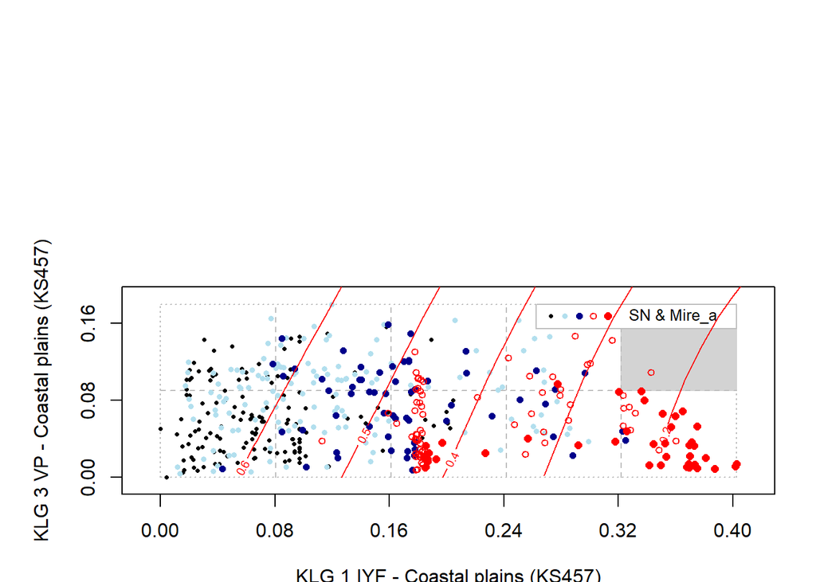

```r
###

#1 IyK mot 3 VP; SN som symboler og isolinjer for Mire_a

par(plt=c(0.15, 0.95, 0.15, y2))
plot(s1,s2,xlab="KLG 1 IYF - Coastal plains (KS457)",ylab="KLG 3 VP - Coastal plains (KS457)",xlim=c(-0.01,max(s1)+0.01),ylim=c(-0.01,max(s2)+0.01),xaxp=c(0,0.4,5),yaxp=c(0,0.4,5),type="n") #Grunnlag for plotting av symboler etc.
lines(c(0,max(s1)),c(max(s2),max(s2)),lty=3,col=8)
lines(c(0,max(s1)),c(0,0),lty=3,col=8)
lines(c(0,0),c(0,max(s2)),lty=3,col=8)
lines(c(max(s1),max(s1)),c(0,max(s2)),lty=3,col=8)

polygon(c(4*max(s1)/5,4*max(s1)/5,max(s1),max(s1)),c(max(s2)/2,max(s2)-0.025,max(s2)-0.025,max(s2)/2),col="lightgray")
polygon(c(4*max(s1)/5,4*max(s1)/5,max(s1),max(s1)),c(max(s2)/2,max(s2)-0.025,max(s2)-0.025,max(s2)/2),col="lightgray",density=10) #legger egentlig et skr?tt raster opp?, og fjerner streken rundt

lines(c(0,max(s1)),c(max(s2)/2,max(s2)/2),lty=2,col=8)
lines(c(0.2*max(s1),0.2*max(s1)),c(0,max(s2)),lty=2,col=8)
lines(c(0.4*max(s1),0.4*max(s1)),c(0,max(s2)),lty=2,col=8)
lines(c(0.6*max(s1),0.6*max(s1)),c(0,max(s2)),lty=2,col=8)
lines(c(0.8*max(s1),0.8*max(s1)),c(0,max(s2)-0.025),lty=2,col=8)

lines(c(max(s1)-0.14,max(s1)),c(max(s2),max(s2)),col=8)
lines(c(max(s1)-0.14,max(s1)),c(max(s2)-0.025,max(s2)-0.025),col=8)
lines(c(max(s1)-0.14,max(s1)-0.14),c(max(s2)-0.025,max(s2)),col=8)
lines(c(max(s1),max(s1)),c(max(s2)-0.025,max(s2)),col=8)

text(max(s1)-0.075,max(s2)-0.012,"SN & Mire_a",adj=0,cex=0.8)
points(max(s1)-0.13,max(s2)-0.012,pch=16,cex=0.5,col="black")
points(max(s1)-0.12,max(s2)-0.012,pch=16,cex=0.6,col="lightblue2")
points(max(s1)-0.11,max(s2)-0.012,pch=16,cex=0.75,col="darkblue")
points(max(s1)-0.10,max(s2)-0.012,pch=1,cex=0.75,col="red")
points(max(s1)-0.09,max(s2)-0.012,pch=16,cex=0.9,col="red")

points(s1[SN==1],s2[SN==1],pch=16,cex=0.5,col=1)
points(s1[SN==2],s2[SN==2],pch=16,cex=0.6,col="lightblue2")
points(s1[SN==3],s2[SN==3],pch=16,cex=0.75,col="darkblue")
points(s1[SN==4],s2[SN==4],pch=1,cex=0.75,col="red")
points(s1[SN==5],s2[SN==5],pch=16,cex=0.9,col="red")

os <- ordisurf(snv[,c(1,3)],Mire_a,display="sites",levels=c(0.05,0.1,0.2,0.3,0.4,0.5,0.6), col="red",add=T) #inkluderer plotting p? eksisterende ordinasjonsdiagram
```

```r
#Fig. 3. 2 RE mot 3 VP; SN som symboler og isolinjer for Inns_s
##Ikke relevant for siste gangs analyse

#sONV'er som skal plottes mot hverandre
s1 <- sONV_RE
s2 <- sONV_VP

#Finner koordinatene for hj?rner i det 'plotteomr?det' med koordinater (x1, x2, y1, y2) som gir
#like enheter p? begge akser. Vi holder x1, x2 og y1 faste og bestemmer y2 slik at (x2-x1)/(y2-y1) i plt=c(x1,x2,y1,y2)
#blir lik max(s1)/max(s2)
#Det krever at y2 = [(x2-x1)*max(s2) + y1*max(s1)]/max(s1)
#Setter vi x1, x2 og y1 konstante, f?r vi:
y2 <- (0.8*max(s2)+0.15*max(s1))/max(s1)
y2
```

```
## [1] 0.6279221
```